# 1 Similar recovery time of microbial functions from fungicide stress across biogeographical regions

Verena C. Schreiner, Alexander Feckler, Diego Fernández, Katharina Frisch, Katherine Muñoz, Eduard Szöcs, Jochen Zubrod, Mirco Bundschuh, Jes J. Rasmussen, Ben J. Kefford, Josepha Axelsen, Nina Cedergreen & Ralf B. Schäfer

R script written by Verena C. Schreiner and Eduard Szöcs  
University of Koblenz-Landau  
Fortstrasse 7  
76829 Landau  
GERMANY  
Corresponding mail adress: schreiner-verena'@'uni-landau.de

## 1.1 Tools / Packages

```r
library(ggplot2)
library(vegan)
library(lsmeans)
library(effects)
library(cowplot)
library(Rmisc)
library(lme4)
require(reshape2)
```

## 1.2 Load & Clean Data

```r
# project path, change to the path you safed the rawfiles
prj <- getwd()

data_all <- read.table(file.path(prj, "rawdata.csv"),
                      header = TRUE,
                      sep = ";",
                      na.strings = c("NR", "NA"))

data_conid <- read.table(file.path(prj, "Raw_Conidia.csv"),
                      header = TRUE,
                      sep = ";",
                      na.strings = c("NR", "NA"))
```

Encode factors.

```r
data_all$Number.replicate <- factor(data_all$Number.replicate)
data_all$cycle <- factor(data_all$cycle)

# recode fungicide order
data_all$fungicide <- factor(data_all$fungicide,
                             levels = c("control", "TU-1"))
str(data_all)
```

```
## 'data.frame':    148 obs. of  10 variables:
##  $ fungicide       : Factor w/ 2 levels "control","TU-1": 1 1 1 1 1 1 1 1 1 1 ...
##  $ cycle           : Factor w/ 3 levels "1","2","3": 1 1 1 1 1 1 1 1 1 1 ...
##  $ Number.replicate: Factor w/ 7 levels "1","2","3","4",..: 1 2 3 4 5 6 7 1 2 3 ...
##  $ OMD             : num  0.000981 0.002158 0.001642 0.002094 0.002381 ...
##  $ region          : Factor w/ 4 levels "Australia","Denmark",..: 2 2 2 2 2 2 2 3 3 3 ...
##  $ Temp_field      : num  9 9 9 9 9 9 9 7.57 7.57 7.57 ...
##  $ Temp_lab        : num  15 15 15 15 15 ...
##  $ weight.start    : num  2000 2000 2000 2000 2000 ...
##  $ weight.end      : num  1520 1093 1263 1113 1027 ...
##  $ species         : int  18 8 12 13 9 15 9 NA NA NA ...
```

```r
data_conid$Number.replicate <- factor(data_conid$Number.replicate)
data_conid$cycle <- factor(data_conid$cycle)

# recode fungicide order
data_conid$fungicide <- factor(data_conid$fungicide,
                             levels = c("control", "TU-1"))
```

### 1.2.1 explanatory variables

- region (factor; categorical; Denmark, Germany, Sweden and Australia)
- fungicide (factor; categorical; control and treated)
- cycle (factor; categorical; 1, 2, and 3)

### 1.2.2 Calculting decomposed leaf mass (DLM)

The data from this endpint are % of lost leaf mass, divided with number degreedays (to normalise for temperature differences)

```r
data_all$DLM <- ifelse(data_all$cycle =="1",
                       (((data_all$weight.start - data_all$weight.end)
                         / data_all$weight.start)
                        / ((1*data_all$Temp_field + 2*data_all$Temp_lab)/3)),
                       ((data_all$weight.start - data_all$weight.end)
                        / data_all$weight.start) / (data_all$Temp_lab))
```

### 1.2.3 calculating DLM of fungicide treatment relative to respective controls

change formatting of data

```r
data_all_OMD <- data_all[,c(1,2,3,5,11)]

data_all_OMD_control_u <- data_all_OMD[data_all_OMD$fungicide == "control",]
data_all_OMD_control <-  melt(data_all_OMD_control_u,
                              id = c("fungicide", "cycle", "region",
                                     "Number.replicate"))

data_all_OMD_control <- dcast(data_all_OMD_control, fungicide + cycle + region ~ variable,
                              mean)

data_all_OMD_control <- merge(data_all_OMD_control_u[-5], data_all_OMD_control,
                              by=c("fungicide", "cycle", "region"))
names(data_all_OMD_control)[5] <- c("control")
data_all_OMD_control <- data_all_OMD_control[-1]

data_all_OMD_trt <- data_all_OMD[! data_all_OMD$fungicide == "control",]
data_all_OMD_trt <- data_all_OMD_trt[-1]

data_all_OMD_perc <- merge(data_all_OMD_control, data_all_OMD_trt,
                           by=c("cycle", "region", "Number.replicate"))
names(data_all_OMD_perc)[5] <- c("treatment")
```

calulating relative differences of fungicide treatment to the respective controls

```r
data_all_OMD_perc$diff <- ((data_all_OMD_perc$treatment - data_all_OMD_perc$control) /
                             data_all_OMD_perc$control)*100
```

remove the biogeographical region of Australia

```r
data_all_OMD_perc <- data_all_OMD_perc[!data_all_OMD_perc$region == "Australia",]
```

### 1.2.4 dividing dataset into different biogeographical regions

- Germany

```r
data_ger <- subset(data_all, region == 'Germany')
rownames(data_ger) <- NULL

data_conid_DE <- subset(data_conid, Region == 'DE')
rownames(data_conid_DE) <- NULL

conid_DE <- data_conid_DE[,c(5:63)]

Fak_conid_DE <- data_conid_DE[,c(1:4)]
Fak_conid_DE <- droplevels(Fak_conid_DE)
```

- Sweden

```r
data_SW <- subset(data_all, region == 'Sweden')
rownames(data_SW) <- NULL

data_conid_SW <- subset(data_conid, Region == 'SW')
rownames(data_conid_SW) <- NULL

conid_SW <- data_conid_SW[,c(5:63)]

Fak_conid_SW <- data_conid_SW[,c(1:4)]
Fak_conid_SW <- droplevels(Fak_conid_SW)
```

- Denmark

```r
data_DK <- subset(data_all, region == 'Denmark')
rownames(data_DK) <- NULL

data_conid_DK <- subset(data_conid, Region == 'DK')
rownames(data_conid_DK) <- NULL

conid_DK <- data_conid_DK[,c(5:63)]

Fak_conid_DK <- data_conid_DK[,c(1:4)]
Fak_conid_DK <- droplevels(Fak_conid_DK)
```

- Australia

```r
data_AUS <- subset(data_all, region == 'Australia')
rownames(data_AUS) <- NULL
```

## 1.3 decomposed leaf mass (DLM) -> functional response

### 1.3.1 all biogeographical regions

#### 1.3.1.1 Model the data

##### 1.3.1.1.1 Fit model

Using a mixed model where the replicates are a random effect, which is nested in the regions

```r
mod1_all_OMD_perc <- lmer(diff ~ region + cycle + region:cycle +
                            (region | Number.replicate),
                          data = data_all_OMD_perc)
```

##### 1.3.1.1.2 Diagnose model

First we check some model diagnostics:

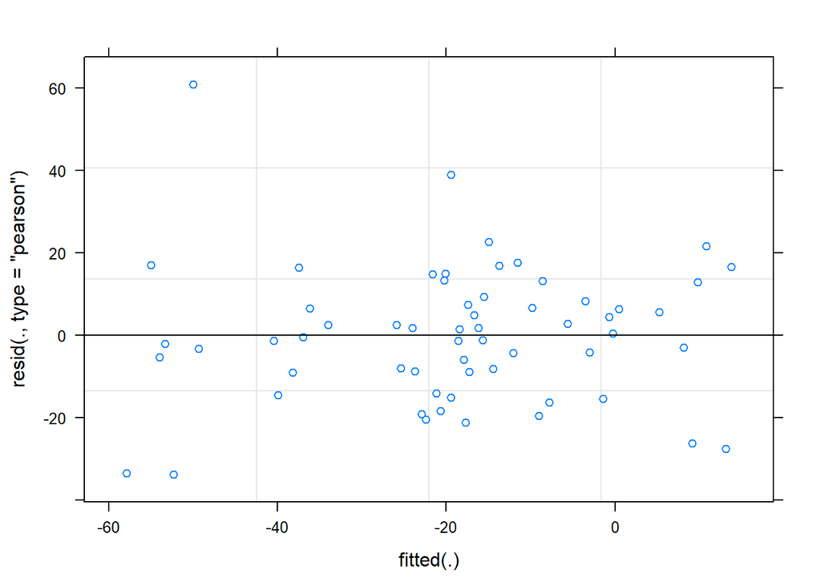

```r
par(mfrow = c(2, 2))
plot(mod1_all_OMD_perc)
```

Model fits.

##### 1.3.1.1.3 Investigate significance

```r
drop1(mod1_all_OMD_perc, test = 'Chisq')
```

```
## Single term deletions
##
## Model:
## diff ~ region + cycle + region:cycle + (region | Number.replicate)
##              Df    AIC    LRT   Pr(Chi)
## <none>          543.74
## region:cycle  4 554.90 19.159 0.0007314 ***
## ---
## Signif. codes:  0 '***' 0.001 '**' 0.01 '*' 0.05 '.' 0.1 ' ' 1
```

### 1.3.2 Germany

#### 1.3.2.1 Model the data

##### 1.3.2.1.1 Fit model

We fit our model using:

```r
mod1_DE_OMD <- lm(DLM ~ fungicide + cycle + fungicide:cycle,
                  data = data_ger)
```

##### 1.3.2.1.2 Diagnose model

First we check some model diagnostics:

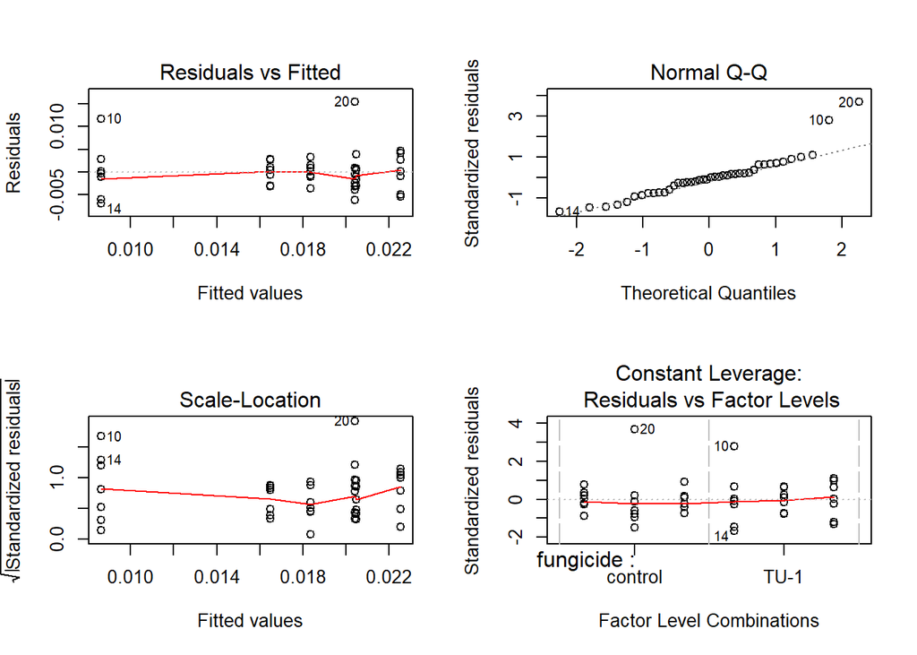

```r
par(mfrow = c(2, 2))
plot(mod1_DE_OMD)
```

Model fits.

##### 1.3.2.1.3 Investigate interactions

```r
drop1(mod1_DE_OMD, test = 'F')
```

```
## Single term deletions
##
## Model:
## DLM ~ fungicide + cycle + fungicide:cycle
##                 Df  Sum of Sq        RSS     AIC F value   Pr(>F)
## <none>                        0.00074242 -447.62
## fungicide:cycle  2 0.00024382 0.00098624 -439.69  5.9114 0.006026 **
## ---
## Signif. codes:  0 '***' 0.001 '**' 0.01 '*' 0.05 '.' 0.1 ' ' 1
```

This indicates a significant interaction between fungicide and cycle.

##### 1.3.2.1.4 Detailed look at parameters

Let’s futher investigate the differences using least-square means (lsmeans).

This calculates the lsmeans for fungicides within each cycle.

```r
lsm_Germany <- lsmeans(mod1_DE_OMD, ~ fungicide | cycle)

lsm_dunn <- contrast(lsm_Germany, 'trt.vs.ctrl')
(lsm_dunn_sum <- summary(lsm_dunn, infer = TRUE, adjust = 'mvt'))
```

```
## cycle = 1:
##  contrast           estimate          SE df     lower.CL      upper.CL
##  TU-1 - control -0.009752605 0.002427394 36 -0.014675589 -0.0048296216
##  t.ratio p.value
##   -4.018  0.0003
##
## cycle = 2:
##  contrast           estimate          SE df     lower.CL      upper.CL
##  TU-1 - control -0.003932574 0.002427394 36 -0.008855558  0.0009904093
##  t.ratio p.value
##   -1.620  0.1139
##
## cycle = 3:
##  contrast           estimate          SE df     lower.CL      upper.CL
##  TU-1 - control  0.002050602 0.002427394 36 -0.002872382  0.0069735853
##  t.ratio p.value
##    0.845  0.4038
##
## Confidence level used: 0.95
```

### 1.3.3 Sweden

#### 1.3.3.1 Model the data

##### 1.3.3.1.1 Fit model

We fit our model using:

```r
mod1_SW_OMD <- lm(DLM ~ fungicide + cycle + fungicide:cycle,
                  data = data_SW)
```

##### 1.3.3.1.2 Diagnose model

First we check some model diagnostics:

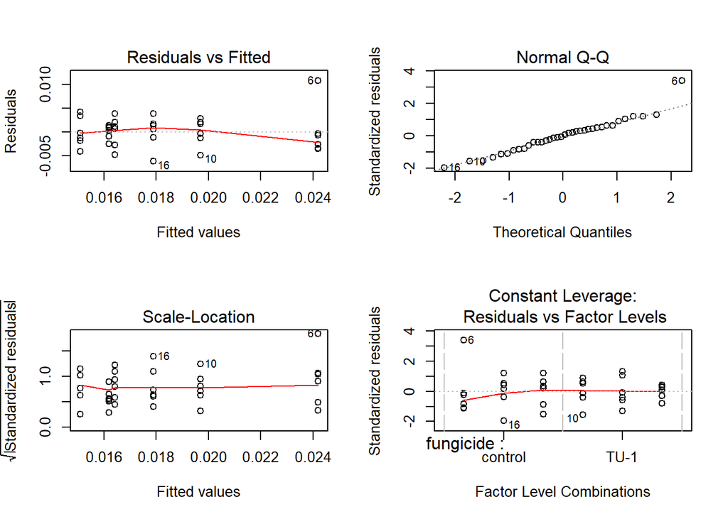

```r
par(mfrow = c(2, 2))
plot(mod1_SW_OMD)
```

Model fits.

##### 1.3.3.1.3 Investigate interactions

Let’s move on to test the interactions.

```r
drop1(mod1_SW_OMD, test = 'F')
```

```
## Single term deletions
##
## Model:
## DLM ~ fungicide + cycle + fungicide:cycle
##                 Df  Sum of Sq        RSS     AIC F value Pr(>F)
## <none>                        0.00036290 -402.18
## fungicide:cycle  2 2.7619e-05 0.00039052 -403.54  1.1416 0.3328
```

This indicates a non-significant interaction between fungicide and cycle, repeat with an easier model without interaction.

##### 1.3.3.1.4 Fit model without interaction

```r
mod1_SW_OMD_2 <- lm(DLM ~ fungicide + cycle,
           data = data_SW)
```

##### 1.3.3.1.5 Diagnose model without interaction

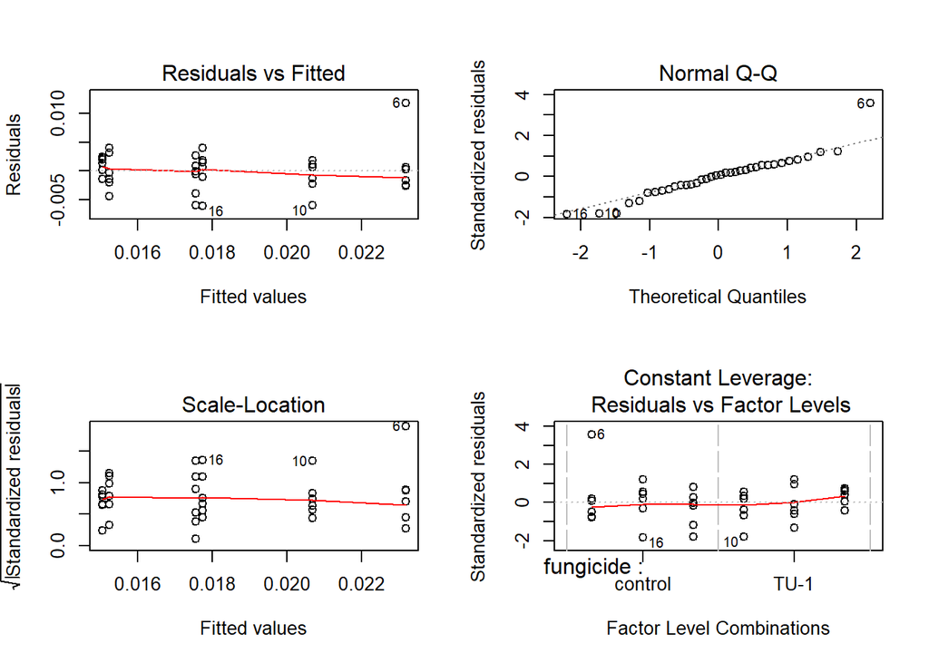

```r
par(mfrow = c(2, 2))
plot(mod1_SW_OMD_2)
```

Model fits

##### 1.3.3.1.6 Investigate significance of parameters

```r
drop1(mod1_SW_OMD_2, test = 'F')
```

```
## Single term deletions
##
## Model:
## DLM ~ fungicide + cycle
##           Df  Sum of Sq        RSS     AIC F value    Pr(>F)
## <none>                  0.00039052 -403.54
## fungicide  1 5.6599e-05 0.00044712 -400.66  4.6379 0.0389118 *
## cycle      2 2.4595e-04 0.00063647 -389.95 10.0769 0.0004035 ***
## ---
## Signif. codes:  0 '***' 0.001 '**' 0.01 '*' 0.05 '.' 0.1 ' ' 1
```

##### 1.3.3.1.7 Detailed look at paramaters

Let’s futher investigate the differences using least-square means (lsmeans).

This calculates the lsmeans for fungicides within each cycle.

```r
lsm_Sweden <- lsmeans(mod1_SW_OMD, ~ fungicide | cycle)

lsm_dunn <- contrast(lsm_Sweden, 'trt.vs.ctrl')
(lsm_dunn_sum <- summary(lsm_dunn, infer = TRUE, adjust = 'mvt'))
```

```
## cycle = 1:
##  contrast            estimate          SE df     lower.CL     upper.CL
##  TU-1 - control -0.0044955696 0.002008036 30 -0.008596527 -0.000394612
##  t.ratio p.value
##   -2.239  0.0327
##
## cycle = 2:
##  contrast            estimate          SE df     lower.CL     upper.CL
##  TU-1 - control -0.0027942762 0.002008036 30 -0.006895234  0.001306681
##  t.ratio p.value
##   -1.392  0.1743
##
## cycle = 3:
##  contrast            estimate          SE df     lower.CL     upper.CL
##  TU-1 - control -0.0002333904 0.002008036 30 -0.004334348  0.003867567
##  t.ratio p.value
##   -0.116  0.9082
##
## Confidence level used: 0.95
```

### 1.3.4 Denmark

#### 1.3.4.1 Model the data

##### 1.3.4.1.1 Fit model

We fit our model using:

```r
mod1_DK_OMD <- lm(DLM ~ fungicide + cycle + fungicide:cycle,
               data = data_DK)
```

##### 1.3.4.1.2 Diagnose model

First we check some model diagnostics:

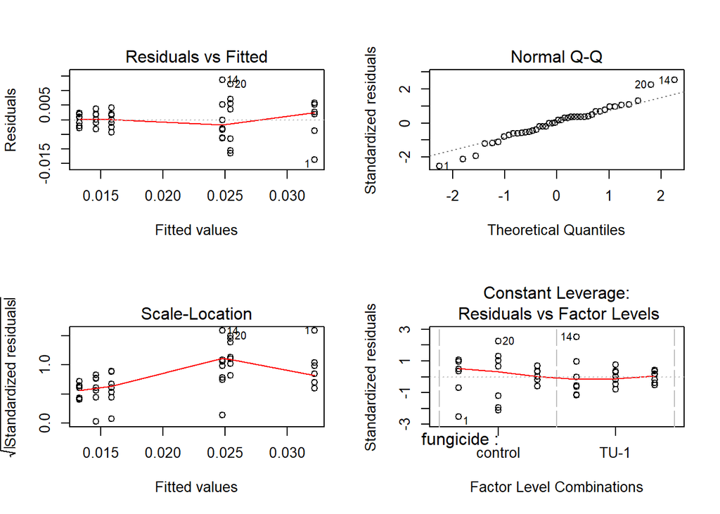

```r
par(mfrow = c(2, 2))
plot(mod1_DK_OMD)
```

Model fits.

##### 1.3.4.1.3 Investigate interactions

Let’s move on to test the interactions.

```r
drop1(mod1_DK_OMD, test = 'F')
```

```
## Single term deletions
##
## Model:
## DLM ~ fungicide + cycle + fungicide:cycle
##                 Df  Sum of Sq       RSS     AIC F value Pr(>F)
## <none>                        0.0012392 -426.10
## fungicide:cycle  2 0.00012731 0.0013665 -425.99  1.8493  0.172
```

This indicates a non-significant interaction between fungicide and cycle, repeat with an easier model without interaction.

##### 1.3.4.1.4 Fit model withour interaction

```r
mod1_DK_OMD_2 <- lm(DLM ~ fungicide + cycle,
                 data = data_DK)
```

##### 1.3.4.1.5 Diagnose model without interaction

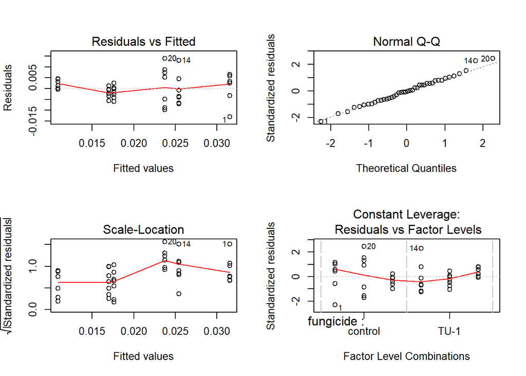

```r
par(mfrow = c(2, 2))
plot(mod1_DK_OMD_2)
```

##### 1.3.4.1.6 Investigate significance of parameters

```r
drop1(mod1_DK_OMD_2, test = 'F')
```

```
## Single term deletions
##
## Model:
## DLM ~ fungicide + cycle
##           Df  Sum of Sq       RSS     AIC F value    Pr(>F)
## <none>                  0.0013665 -425.99
## fungicide  1 0.00039207 0.0017586 -417.40  10.903  0.002097 **
## cycle      2 0.00148620 0.0028527 -399.08  20.664 8.449e-07 ***
## ---
## Signif. codes:  0 '***' 0.001 '**' 0.01 '*' 0.05 '.' 0.1 ' ' 1
```

##### 1.3.4.1.7 Detailed look at parameters

Let’s futher investigate the differences using least-square means (lsmeans).

This calculates the lsmeans for fungicides within each cycle.

```r
lsm_Denmark <- lsmeans(mod1_DK_OMD, ~ fungicide | cycle)

lsm_dunn <- contrast(lsm_Denmark, 'trt.vs.ctrl')
(lsm_dunn_sum <- summary(lsm_dunn, infer = TRUE, adjust = 'mvt'))
```

```
## cycle = 1:
##  contrast           estimate          SE df     lower.CL     upper.CL
##  TU-1 - control -0.007425926 0.003136088 36 -0.013786207 -0.001065645
##  t.ratio p.value
##   -2.368  0.0234
##
## cycle = 2:
##  contrast           estimate          SE df     lower.CL     upper.CL
##  TU-1 - control -0.009562789 0.003136088 36 -0.015923070 -0.003202508
##  t.ratio p.value
##   -3.049  0.0043
##
## cycle = 3:
##  contrast           estimate          SE df     lower.CL     upper.CL
##  TU-1 - control -0.001343265 0.003136088 36 -0.007703546  0.005017016
##  t.ratio p.value
##   -0.428  0.6710
##
## Confidence level used: 0.95
```

## 1.4 Hyphomycete community resposes -> structural response

In Germany only data from cycle 2 + 3 available, due to technical difficulties.

### 1.4.1 Germany

##### 1.4.1.0.1 Making RDA

Repeating RDA (and related Anovas) with different numbers and composition of explanatory variables, to be able to calculate effects sizes and p-values individually for each exlenatory variable.

```r
rda_species_DE_1 <- rda(decostand(conid_DE, "hellinger")
                        ~ cycle, data = Fak_conid_DE)
summary(rda_species_DE_1, display = NULL)
```

```
##
## Call:
## rda(formula = decostand(conid_DE, "hellinger") ~ cycle, data = Fak_conid_DE)
##
## Partitioning of variance:
##               Inertia Proportion
## Total          0.2455      1.000
## Constrained    0.0405      0.165
## Unconstrained  0.2050      0.835
##
## Eigenvalues, and their contribution to the variance
##
## Importance of components:
##                         RDA1     PC1     PC2     PC3     PC4     PC5
## Eigenvalue            0.0405 0.07425 0.03783 0.02714 0.02306 0.01544
## Proportion Explained  0.1650 0.30242 0.15411 0.11056 0.09392 0.06290
## Cumulative Proportion 0.1650 0.46740 0.62151 0.73207 0.82599 0.88889
##                           PC6      PC7      PC8      PC9     PC10    PC11
## Eigenvalue            0.01176 0.004367 0.002903 0.002404 0.002202 0.00151
## Proportion Explained  0.04791 0.017790 0.011820 0.009790 0.008970 0.00615
## Cumulative Proportion 0.93680 0.954590 0.966410 0.976210 0.985180 0.99133
##                            PC12     PC13      PC14      PC15      PC16
## Eigenvalue            0.0008661 0.000533 0.0003447 0.0001653 0.0001169
## Proportion Explained  0.0035300 0.002170 0.0014000 0.0006700 0.0004800
## Cumulative Proportion 0.9948500 0.997020 0.9984300 0.9991000 0.9995800
##                            PC17      PC18
## Eigenvalue            9.827e-05 5.374e-06
## Proportion Explained  4.000e-04 2.000e-05
## Cumulative Proportion 1.000e+00 1.000e+00
##
## Accumulated constrained eigenvalues
## Importance of components:
##                         RDA1
## Eigenvalue            0.0405
## Proportion Explained  1.0000
## Cumulative Proportion 1.0000
##
## Scaling 2 for species and site scores
## * Species are scaled proportional to eigenvalues
## * Sites are unscaled: weighted dispersion equal on all dimensions
## * General scaling constant of scores:
```

```r
anova(rda_species_DE_1, by = "margin")
```

```
## Permutation test for rda under NA model
## Marginal effects of terms
## Permutation: free
## Number of permutations: 999
##
## Model: rda(formula = decostand(conid_DE, "hellinger") ~ cycle, data = Fak_conid_DE)
##          Df Variance      F Pr(>F)
## cycle     1 0.040504 3.5564  0.001 ***
## Residual 18 0.205001
## ---
## Signif. codes:  0 '***' 0.001 '**' 0.01 '*' 0.05 '.' 0.1 ' ' 1
```

```r
rda_species_DE_2 <- rda(decostand(conid_DE, "hellinger")
                        ~ fungicide, data = Fak_conid_DE)
summary(rda_species_DE_2, display = NULL)
```

```
##
## Call:
## rda(formula = decostand(conid_DE, "hellinger") ~ fungicide, data = Fak_conid_DE)
##
## Partitioning of variance:
##               Inertia Proportion
## Total         0.24551    1.00000
## Constrained   0.01554    0.06329
## Unconstrained 0.22997    0.93671
##
## Eigenvalues, and their contribution to the variance
##
## Importance of components:
##                          RDA1     PC1     PC2     PC3     PC4     PC5
## Eigenvalue            0.01554 0.08309 0.04452 0.03499 0.02376 0.01925
## Proportion Explained  0.06329 0.33843 0.18134 0.14250 0.09677 0.07843
## Cumulative Proportion 0.06329 0.40172 0.58305 0.72556 0.82232 0.90075
##                           PC6      PC7      PC8      PC9    PC10     PC11
## Eigenvalue            0.01025 0.004653 0.002562 0.002342 0.00167 0.001308
## Proportion Explained  0.04175 0.018950 0.010430 0.009540 0.00680 0.005330
## Cumulative Proportion 0.94250 0.961460 0.971890 0.981430 0.98823 0.993560
##                            PC12     PC13      PC14      PC15      PC16
## Eigenvalue            0.0005423 0.000426 0.0002572 0.0001479 0.0001175
## Proportion Explained  0.0022100 0.001740 0.0010500 0.0006000 0.0004800
## Cumulative Proportion 0.9957700 0.997500 0.9985500 0.9991500 0.9996300
##                            PC17      PC18
## Eigenvalue            7.016e-05 2.054e-05
## Proportion Explained  2.900e-04 8.000e-05
## Cumulative Proportion 9.999e-01 1.000e+00
##
## Accumulated constrained eigenvalues
## Importance of components:
##                          RDA1
## Eigenvalue            0.01554
## Proportion Explained  1.00000
## Cumulative Proportion 1.00000
##
## Scaling 2 for species and site scores
## * Species are scaled proportional to eigenvalues
## * Sites are unscaled: weighted dispersion equal on all dimensions
## * General scaling constant of scores:
```

```r
anova(rda_species_DE_2, by = "margin")
```

```
## Permutation test for rda under NA model
## Marginal effects of terms
## Permutation: free
## Number of permutations: 999
##
## Model: rda(formula = decostand(conid_DE, "hellinger") ~ fungicide, data = Fak_conid_DE)
##           Df Variance      F Pr(>F)
## fungicide  1 0.015537 1.2161  0.309
## Residual  18 0.229968
```

```r
rda_species_DE_3 <- rda(decostand(conid_DE, "hellinger")
                        ~ cycle + fungicide + fungicide:cycle, data = Fak_conid_DE)
summary(rda_species_DE_3, display = NULL)
```

```
##
## Call:
## rda(formula = decostand(conid_DE, "hellinger") ~ cycle + fungicide +      fungicide:cycle, data = Fak_conid_DE)
##
## Partitioning of variance:
##               Inertia Proportion
## Total         0.24551     1.0000
## Constrained   0.06852     0.2791
## Unconstrained 0.17699     0.7209
##
## Eigenvalues, and their contribution to the variance
##
## Importance of components:
##                         RDA1    RDA2     RDA3     PC1     PC2     PC3
## Eigenvalue            0.0447 0.01469 0.009122 0.06439 0.03432 0.02303
## Proportion Explained  0.1821 0.05984 0.037160 0.26226 0.13980 0.09379
## Cumulative Proportion 0.1821 0.24192 0.279080 0.54134 0.68114 0.77493
##                           PC4     PC5     PC6      PC7     PC8      PC9
## Eigenvalue            0.01857 0.01461 0.01021 0.004205 0.00236 0.001848
## Proportion Explained  0.07562 0.05952 0.04157 0.017130 0.00961 0.007530
## Cumulative Proportion 0.85055 0.91007 0.95165 0.968770 0.97839 0.985910
##                           PC10      PC11     PC12      PC13      PC14
## Eigenvalue            0.001581 0.0009559 0.000418 0.0001836 0.0001372
## Proportion Explained  0.006440 0.0038900 0.001700 0.0007500 0.0005600
## Cumulative Proportion 0.992350 0.9962500 0.997950 0.9987000 0.9992600
##                            PC15      PC16
## Eigenvalue            0.0001162 6.639e-05
## Proportion Explained  0.0004700 2.700e-04
## Cumulative Proportion 0.9997300 1.000e+00
##
## Accumulated constrained eigenvalues
## Importance of components:
##                         RDA1    RDA2     RDA3
## Eigenvalue            0.0447 0.01469 0.009122
## Proportion Explained  0.6524 0.21442 0.133140
## Cumulative Proportion 0.6524 0.86686 1.000000
##
## Scaling 2 for species and site scores
## * Species are scaled proportional to eigenvalues
## * Sites are unscaled: weighted dispersion equal on all dimensions
## * General scaling constant of scores:
```

```r
anova(rda_species_DE_3, by = "margin")
```

```
## Permutation test for rda under reduced model
## Marginal effects of terms
## Permutation: free
## Number of permutations: 999
##
## Model: rda(formula = decostand(conid_DE, "hellinger") ~ cycle + fungicide + fungicide:cycle, data = Fak_conid_DE)
##                 Df Variance      F Pr(>F)
## cycle:fungicide  1 0.012474 1.1276  0.371
## Residual        16 0.176990
```

Since the interaction of fungicide: cycle is not significant using a model with both variables but without interactions for the RDA Graph

```r
rda_species_DE_4 <- rda(decostand(conid_DE, "hellinger")
                        ~ cycle + fungicide, data = Fak_conid_DE)
summary(rda_species_DE_4, display = NULL)
```

```
##
## Call:
## rda(formula = decostand(conid_DE, "hellinger") ~ cycle + fungicide,      data = Fak_conid_DE)
##
## Partitioning of variance:
##               Inertia Proportion
## Total         0.24551     1.0000
## Constrained   0.05604     0.2283
## Unconstrained 0.18946     0.7717
##
## Eigenvalues, and their contribution to the variance
##
## Importance of components:
##                          RDA1    RDA2     PC1     PC2    PC3     PC4
## Eigenvalue            0.04141 0.01463 0.06838 0.03546 0.0260 0.02185
## Proportion Explained  0.16867 0.05961 0.27854 0.14442 0.1059 0.08901
## Cumulative Proportion 0.16867 0.22827 0.50682 0.65123 0.7571 0.84614
##                           PC5     PC6      PC7      PC8      PC9     PC10
## Eigenvalue            0.01464 0.01023 0.004209 0.002412 0.002202 0.001604
## Proportion Explained  0.05965 0.04168 0.017150 0.009820 0.008970 0.006530
## Cumulative Proportion 0.90579 0.94748 0.964620 0.974440 0.983420 0.989950
##                           PC11      PC12      PC13     PC14      PC15
## Eigenvalue            0.001081 0.0005422 0.0003999 0.000169 0.0001286
## Proportion Explained  0.004400 0.0022100 0.0016300 0.000690 0.0005200
## Cumulative Proportion 0.994350 0.9965600 0.9981900 0.998880 0.9994000
##                           PC16      PC17
## Eigenvalue            0.000116 3.141e-05
## Proportion Explained  0.000470 1.300e-04
## Cumulative Proportion 0.999870 1.000e+00
##
## Accumulated constrained eigenvalues
## Importance of components:
##                          RDA1    RDA2
## Eigenvalue            0.04141 0.01463
## Proportion Explained  0.73888 0.26112
## Cumulative Proportion 0.73888 1.00000
##
## Scaling 2 for species and site scores
## * Species are scaled proportional to eigenvalues
## * Sites are unscaled: weighted dispersion equal on all dimensions
## * General scaling constant of scores:
```

```r
anova(rda_species_DE_4, by = "margin")
```

```
## Permutation test for rda under reduced model
## Marginal effects of terms
## Permutation: free
## Number of permutations: 999
##
## Model: rda(formula = decostand(conid_DE, "hellinger") ~ cycle + fungicide, data = Fak_conid_DE)
##           Df Variance      F Pr(>F)
## cycle      1 0.040504 3.6343  0.002 **
## fungicide  1 0.015537 1.3941  0.248
## Residual  17 0.189464
## ---
## Signif. codes:  0 '***' 0.001 '**' 0.01 '*' 0.05 '.' 0.1 ' ' 1
```

### 1.4.2 Sweden

##### 1.4.2.0.1 Making RDA

Repeating RDA (and related Anovas) with different numbers and composition of explanatory variables, to be able to calculate effects sizes and p-values individually for each exlenatory variable.

```r
rda_species_SW_1 <- rda(decostand(conid_SW, "hellinger")
                        ~ cycle, data = Fak_conid_SW)
summary(rda_species_SW_1, display = NULL)
```

```
##
## Call:
## rda(formula = decostand(conid_SW, "hellinger") ~ cycle, data = Fak_conid_SW)
##
## Partitioning of variance:
##                Inertia Proportion
## Total         0.115577    1.00000
## Constrained   0.009243    0.07998
## Unconstrained 0.106333    0.92002
##
## Eigenvalues, and their contribution to the variance
##
## Importance of components:
##                          RDA1     RDA2     PC1     PC2    PC3      PC4
## Eigenvalue            0.00656 0.002683 0.06544 0.01924 0.0118 0.004948
## Proportion Explained  0.05676 0.023220 0.56620 0.16645 0.1021 0.042810
## Cumulative Proportion 0.05676 0.079980 0.64617 0.81263 0.9147 0.957540
##                            PC5     PC6      PC7       PC8       PC9
## Eigenvalue            0.002139 0.00132 0.000717 0.0005306 0.0001594
## Proportion Explained  0.018510 0.01142 0.006200 0.0045900 0.0013800
## Cumulative Proportion 0.976050 0.98747 0.993670 0.9982600 0.9996400
##                            PC10
## Eigenvalue            4.125e-05
## Proportion Explained  3.600e-04
## Cumulative Proportion 1.000e+00
##
## Accumulated constrained eigenvalues
## Importance of components:
##                          RDA1     RDA2
## Eigenvalue            0.00656 0.002683
## Proportion Explained  0.70971 0.290290
## Cumulative Proportion 0.70971 1.000000
##
## Scaling 2 for species and site scores
## * Species are scaled proportional to eigenvalues
## * Sites are unscaled: weighted dispersion equal on all dimensions
## * General scaling constant of scores:
```

```r
anova(rda_species_SW_1, by = "margin")
```

```
## Permutation test for rda under NA model
## Marginal effects of terms
## Permutation: free
## Number of permutations: 999
##
## Model: rda(formula = decostand(conid_SW, "hellinger") ~ cycle, data = Fak_conid_SW)
##          Df Variance      F Pr(>F)
## cycle     2 0.009243 1.3909  0.212
## Residual 32 0.106333
```

```r
rda_species_SW_2 <- rda(decostand(conid_SW, "hellinger")
                        ~ fungicide, data = Fak_conid_SW)
summary(rda_species_SW_2, display = NULL)
```

```
##
## Call:
## rda(formula = decostand(conid_SW, "hellinger") ~ fungicide, data = Fak_conid_SW)
##
## Partitioning of variance:
##               Inertia Proportion
## Total         0.11558     1.0000
## Constrained   0.02494     0.2158
## Unconstrained 0.09064     0.7842
##
## Eigenvalues, and their contribution to the variance
##
## Importance of components:
##                          RDA1     PC1     PC2     PC3      PC4      PC5
## Eigenvalue            0.02494 0.04433 0.02168 0.01514 0.004951 0.001597
## Proportion Explained  0.21579 0.38359 0.18754 0.13097 0.042840 0.013820
## Cumulative Proportion 0.21579 0.59937 0.78692 0.91789 0.960720 0.974540
##                           PC6       PC7       PC8       PC9      PC10
## Eigenvalue            0.00132 0.0008273 0.0005689 0.0001867 3.947e-05
## Proportion Explained  0.01142 0.0071600 0.0049200 0.0016200 3.400e-04
## Cumulative Proportion 0.98596 0.9931200 0.9980400 0.9996600 1.000e+00
##
## Accumulated constrained eigenvalues
## Importance of components:
##                          RDA1
## Eigenvalue            0.02494
## Proportion Explained  1.00000
## Cumulative Proportion 1.00000
##
## Scaling 2 for species and site scores
## * Species are scaled proportional to eigenvalues
## * Sites are unscaled: weighted dispersion equal on all dimensions
## * General scaling constant of scores:
```

```r
anova(rda_species_SW_2, by = "margin")
```

```
## Permutation test for rda under NA model
## Marginal effects of terms
## Permutation: free
## Number of permutations: 999
##
## Model: rda(formula = decostand(conid_SW, "hellinger") ~ fungicide, data = Fak_conid_SW)
##           Df Variance      F Pr(>F)
## fungicide  1 0.024940 9.0804  0.001 ***
## Residual  33 0.090637
## ---
## Signif. codes:  0 '***' 0.001 '**' 0.01 '*' 0.05 '.' 0.1 ' ' 1
```

```r
rda_species_SW_3 <- rda(decostand(conid_SW, "hellinger")
                        ~ cycle + fungicide + fungicide:cycle, data = Fak_conid_SW)
summary(rda_species_SW_3, display = NULL)
```

```
##
## Call:
## rda(formula = decostand(conid_SW, "hellinger") ~ cycle + fungicide +      fungicide:cycle, data = Fak_conid_SW)
##
## Partitioning of variance:
##               Inertia Proportion
## Total         0.11558     1.0000
## Constrained   0.03616     0.3129
## Unconstrained 0.07942     0.6871
##
## Eigenvalues, and their contribution to the variance
##
## Importance of components:
##                          RDA1     RDA2     RDA3      RDA4      RDA5
## Eigenvalue            0.02569 0.007389 0.002605 0.0003265 0.0001493
## Proportion Explained  0.22229 0.063930 0.022540 0.0028200 0.0012900
## Cumulative Proportion 0.22229 0.286220 0.308760 0.3115800 0.3128700
##                           PC1     PC2      PC3      PC4      PC5      PC6
## Eigenvalue            0.04266 0.01884 0.009462 0.004699 0.001266 0.001135
## Proportion Explained  0.36907 0.16303 0.081870 0.040660 0.010950 0.009820
## Cumulative Proportion 0.68194 0.84497 0.926840 0.967500 0.978450 0.988280
##                             PC7       PC8       PC9      PC10
## Eigenvalue            0.0006876 0.0005095 0.0001207 3.723e-05
## Proportion Explained  0.0059500 0.0044100 0.0010400 3.200e-04
## Cumulative Proportion 0.9942300 0.9986300 0.9996800 1.000e+00
##
## Accumulated constrained eigenvalues
## Importance of components:
##                          RDA1     RDA2     RDA3      RDA4      RDA5
## Eigenvalue            0.02569 0.007389 0.002605 0.0003265 0.0001493
## Proportion Explained  0.71047 0.204330 0.072040 0.0090300 0.0041300
## Cumulative Proportion 0.71047 0.914800 0.986840 0.9958700 1.0000000
##
## Scaling 2 for species and site scores
## * Species are scaled proportional to eigenvalues
## * Sites are unscaled: weighted dispersion equal on all dimensions
## * General scaling constant of scores:
```

```r
anova(rda_species_SW_3, by = "margin")
```

```
## Permutation test for rda under reduced model
## Marginal effects of terms
## Permutation: free
## Number of permutations: 999
##
## Model: rda(formula = decostand(conid_SW, "hellinger") ~ cycle + fungicide + fungicide:cycle, data = Fak_conid_SW)
##                 Df Variance      F Pr(>F)
## cycle:fungicide  2 0.002004 0.3659  0.929
## Residual        29 0.079416
```

Since the interaction of fungicide: cycle is not significant using a model with both variables but without interactions for the RDA Graph

```r
rda_species_SW_4 <- rda(decostand(conid_SW, "hellinger")
                        ~ cycle + fungicide, data = Fak_conid_SW)
summary(rda_species_SW_4, display = NULL)
```

```
##
## Call:
## rda(formula = decostand(conid_SW, "hellinger") ~ cycle + fungicide,      data = Fak_conid_SW)
##
## Partitioning of variance:
##               Inertia Proportion
## Total         0.11558     1.0000
## Constrained   0.03416     0.2955
## Unconstrained 0.08142     0.7045
##
## Eigenvalues, and their contribution to the variance
##
## Importance of components:
##                          RDA1     RDA2     RDA3     PC1     PC2     PC3
## Eigenvalue            0.02509 0.006528 0.002544 0.04339 0.01906 0.01003
## Proportion Explained  0.21704 0.056480 0.022010 0.37540 0.16489 0.08678
## Cumulative Proportion 0.21704 0.273520 0.295530 0.67094 0.83583 0.92261
##                            PC4      PC5      PC6       PC7       PC8
## Eigenvalue            0.004936 0.001348 0.001232 0.0007037 0.0005304
## Proportion Explained  0.042710 0.011660 0.010660 0.0060900 0.0045900
## Cumulative Proportion 0.965310 0.976970 0.987640 0.9937200 0.9983100
##                             PC9      PC10
## Eigenvalue            0.0001563 3.864e-05
## Proportion Explained  0.0013500 3.300e-04
## Cumulative Proportion 0.9996700 1.000e+00
##
## Accumulated constrained eigenvalues
## Importance of components:
##                          RDA1     RDA2     RDA3
## Eigenvalue            0.02509 0.006528 0.002544
## Proportion Explained  0.73441 0.191110 0.074480
## Cumulative Proportion 0.73441 0.925520 1.000000
##
## Scaling 2 for species and site scores
## * Species are scaled proportional to eigenvalues
## * Sites are unscaled: weighted dispersion equal on all dimensions
## * General scaling constant of scores:
```

```r
anova(rda_species_SW_4, by = "margin")
```

```
## Permutation test for rda under reduced model
## Marginal effects of terms
## Permutation: free
## Number of permutations: 999
##
## Model: rda(formula = decostand(conid_SW, "hellinger") ~ cycle + fungicide, data = Fak_conid_SW)
##           Df Variance      F Pr(>F)
## cycle      2 0.009217 1.7546  0.109
## fungicide  1 0.024914 9.4857  0.001 ***
## Residual  31 0.081420
## ---
## Signif. codes:  0 '***' 0.001 '**' 0.01 '*' 0.05 '.' 0.1 ' ' 1
```

### 1.4.3 Denmark

##### 1.4.3.0.1 Making RDA

Repeating RDA (and related Anovas) with different numbers and composition of explanatory variables, to be able to calculate effects sizes and p-values individually for each exlenatory variable.

```r
rda_species_DK_1 <- rda(decostand(conid_DK, "hellinger")
                        ~ cycle, data = Fak_conid_DK)
summary(rda_species_DK_1, display = NULL)
```

```
##
## Call:
## rda(formula = decostand(conid_DK, "hellinger") ~ cycle, data = Fak_conid_DK)
##
## Partitioning of variance:
##               Inertia Proportion
## Total          0.2502      1.000
## Constrained    0.1034      0.413
## Unconstrained  0.1469      0.587
##
## Eigenvalues, and their contribution to the variance
##
## Importance of components:
##                          RDA1    RDA2     PC1     PC2     PC3     PC4
## Eigenvalue            0.09094 0.01241 0.04721 0.02346 0.01664 0.01089
## Proportion Explained  0.36342 0.04961 0.18865 0.09376 0.06651 0.04351
## Cumulative Proportion 0.36342 0.41304 0.60169 0.69544 0.76196 0.80546
##                            PC5     PC6      PC7      PC8      PC9    PC10
## Eigenvalue            0.009182 0.00646 0.005659 0.005116 0.004345 0.00387
## Proportion Explained  0.036690 0.02581 0.022620 0.020440 0.017360 0.01547
## Cumulative Proportion 0.842160 0.86797 0.890590 0.911030 0.928400 0.94386
##                           PC11     PC12     PC13     PC14     PC15
## Eigenvalue            0.002607 0.002554 0.001833 0.001585 0.001326
## Proportion Explained  0.010420 0.010210 0.007330 0.006330 0.005300
## Cumulative Proportion 0.954280 0.964490 0.971810 0.978150 0.983450
##                           PC16      PC17      PC18      PC19      PC20
## Eigenvalue            0.001063 0.0008915 0.0006092 0.0004409 0.0003225
## Proportion Explained  0.004250 0.0035600 0.0024300 0.0017600 0.0012900
## Cumulative Proportion 0.987690 0.9912600 0.9936900 0.9954500 0.9967400
##                            PC21      PC22      PC23      PC24      PC25
## Eigenvalue            0.0002332 0.0001334 0.0001243 0.0001067 7.916e-05
## Proportion Explained  0.0009300 0.0005300 0.0005000 0.0004300 3.200e-04
## Cumulative Proportion 0.9976700 0.9982100 0.9987000 0.9991300 9.994e-01
##                            PC26      PC27      PC28      PC29      PC30
## Eigenvalue            5.097e-05 3.276e-05 2.342e-05 1.827e-05 7.969e-06
## Proportion Explained  2.000e-04 1.300e-04 9.000e-05 7.000e-05 3.000e-05
## Cumulative Proportion 9.997e-01 9.998e-01 9.999e-01 1.000e+00 1.000e+00
##                            PC31
## Eigenvalue            5.372e-06
## Proportion Explained  2.000e-05
## Cumulative Proportion 1.000e+00
##
## Accumulated constrained eigenvalues
## Importance of components:
##                          RDA1    RDA2
## Eigenvalue            0.09094 0.01241
## Proportion Explained  0.87988 0.12012
## Cumulative Proportion 0.87988 1.00000
##
## Scaling 2 for species and site scores
## * Species are scaled proportional to eigenvalues
## * Sites are unscaled: weighted dispersion equal on all dimensions
## * General scaling constant of scores:
```

```r
anova(rda_species_DK_1, by = "margin")
```

```
## Permutation test for rda under NA model
## Marginal effects of terms
## Permutation: free
## Number of permutations: 999
##
## Model: rda(formula = decostand(conid_DK, "hellinger") ~ cycle, data = Fak_conid_DK)
##          Df Variance      F Pr(>F)
## cycle     2  0.10336 13.722  0.001 ***
## Residual 39  0.14688
## ---
## Signif. codes:  0 '***' 0.001 '**' 0.01 '*' 0.05 '.' 0.1 ' ' 1
```

```r
rda_species_DK_2 <- rda(decostand(conid_DK, "hellinger")
                        ~ fungicide, data = Fak_conid_DK)
summary(rda_species_DK_2, display = NULL)
```

```
##
## Call:
## rda(formula = decostand(conid_DK, "hellinger") ~ fungicide, data = Fak_conid_DK)
##
## Partitioning of variance:
##                Inertia Proportion
## Total         0.250233    1.00000
## Constrained   0.007472    0.02986
## Unconstrained 0.242761    0.97014
##
## Eigenvalues, and their contribution to the variance
##
## Importance of components:
##                           RDA1    PC1     PC2    PC3     PC4     PC5
## Eigenvalue            0.007472 0.1036 0.04283 0.0270 0.01333 0.01052
## Proportion Explained  0.029860 0.4141 0.17115 0.1079 0.05329 0.04204
## Cumulative Proportion 0.029860 0.4439 0.61509 0.7230 0.77628 0.81833
##                            PC6      PC7      PC8      PC9     PC10
## Eigenvalue            0.008088 0.007326 0.005163 0.004514 0.004128
## Proportion Explained  0.032320 0.029280 0.020630 0.018040 0.016500
## Cumulative Proportion 0.850650 0.879920 0.900560 0.918590 0.935090
##                           PC11     PC12     PC13     PC14     PC15
## Eigenvalue            0.002969 0.002485 0.002306 0.001837 0.001708
## Proportion Explained  0.011860 0.009930 0.009220 0.007340 0.006830
## Cumulative Proportion 0.946950 0.956880 0.966100 0.973440 0.980260
##                           PC16     PC17      PC18      PC19      PC20
## Eigenvalue            0.001337 0.000998 0.0007424 0.0004489 0.0004032
## Proportion Explained  0.005340 0.003990 0.0029700 0.0017900 0.0016100
## Cumulative Proportion 0.985610 0.989600 0.9925600 0.9943600 0.9959700
##                            PC21      PC22      PC23      PC24      PC25
## Eigenvalue            0.0002991 0.0002065 0.0001442 9.942e-05 9.113e-05
## Proportion Explained  0.0012000 0.0008300 0.0005800 4.000e-04 3.600e-04
## Cumulative Proportion 0.9971600 0.9979900 0.9985600 9.990e-01 9.993e-01
##                            PC26      PC27      PC28      PC29      PC30
## Eigenvalue            6.004e-05 4.518e-05 2.581e-05 1.803e-05 1.125e-05
## Proportion Explained  2.400e-04 1.800e-04 1.000e-04 7.000e-05 4.000e-05
## Cumulative Proportion 9.996e-01 9.998e-01 9.999e-01 9.999e-01 1.000e+00
##                            PC31
## Eigenvalue            8.321e-06
## Proportion Explained  3.000e-05
## Cumulative Proportion 1.000e+00
##
## Accumulated constrained eigenvalues
## Importance of components:
##                           RDA1
## Eigenvalue            0.007472
## Proportion Explained  1.000000
## Cumulative Proportion 1.000000
##
## Scaling 2 for species and site scores
## * Species are scaled proportional to eigenvalues
## * Sites are unscaled: weighted dispersion equal on all dimensions
## * General scaling constant of scores:
```

```r
anova(rda_species_DK_2, by = "margin")
```

```
## Permutation test for rda under NA model
## Marginal effects of terms
## Permutation: free
## Number of permutations: 999
##
## Model: rda(formula = decostand(conid_DK, "hellinger") ~ fungicide, data = Fak_conid_DK)
##           Df Variance      F Pr(>F)
## fungicide  1 0.007472 1.2311  0.259
## Residual  40 0.242761
```

```r
rda_species_DK_3 <- rda(decostand(conid_DK, "hellinger")
                        ~ cycle + fungicide + fungicide:cycle, data = Fak_conid_DK)
summary(rda_species_DK_3, display = NULL)
```

```
##
## Call:
## rda(formula = decostand(conid_DK, "hellinger") ~ cycle + fungicide +      fungicide:cycle, data = Fak_conid_DK)
##
## Partitioning of variance:
##               Inertia Proportion
## Total          0.2502     1.0000
## Constrained    0.1338     0.5349
## Unconstrained  0.1164     0.4651
##
## Eigenvalues, and their contribution to the variance
##
## Importance of components:
##                          RDA1    RDA2    RDA3     RDA4    RDA5     PC1
## Eigenvalue            0.09572 0.01681 0.01271 0.006957 0.00165 0.03837
## Proportion Explained  0.38253 0.06717 0.05081 0.027800 0.00659 0.15334
## Cumulative Proportion 0.38253 0.44969 0.50050 0.528300 0.53490 0.68824
##                           PC2     PC3      PC4      PC5     PC6      PC7
## Eigenvalue            0.01811 0.01345 0.007946 0.006791 0.00515 0.004864
## Proportion Explained  0.07239 0.05375 0.031750 0.027140 0.02058 0.019440
## Cumulative Proportion 0.76062 0.81438 0.846130 0.873270 0.89386 0.913300
##                            PC8      PC9     PC10     PC11     PC12
## Eigenvalue            0.003999 0.003758 0.002882 0.002009 0.001831
## Proportion Explained  0.015980 0.015020 0.011520 0.008030 0.007320
## Cumulative Proportion 0.929280 0.944300 0.955810 0.963840 0.971160
##                           PC13     PC14     PC15      PC16      PC17
## Eigenvalue            0.001697 0.001411 0.001017 0.0008506 0.0006165
## Proportion Explained  0.006780 0.005640 0.004060 0.0034000 0.0024600
## Cumulative Proportion 0.977940 0.983580 0.987640 0.9910400 0.9935000
##                            PC18      PC19     PC20      PC21      PC22
## Eigenvalue            0.0004261 0.0003738 0.000284 0.0001642 0.0001164
## Proportion Explained  0.0017000 0.0014900 0.001130 0.0006600 0.0004700
## Cumulative Proportion 0.9952100 0.9967000 0.997830 0.9984900 0.9989600
##                            PC23      PC24      PC25      PC26      PC27
## Eigenvalue            7.187e-05 6.345e-05 4.014e-05 2.959e-05 0.0000251
## Proportion Explained  2.900e-04 2.500e-04 1.600e-04 1.200e-04 0.0001000
## Cumulative Proportion 9.992e-01 9.995e-01 9.997e-01 9.998e-01 0.9998800
##                            PC28      PC29      PC30      PC31
## Eigenvalue            1.834e-05 7.262e-06 4.103e-06 1.361e-06
## Proportion Explained  7.000e-05 3.000e-05 2.000e-05 1.000e-05
## Cumulative Proportion 1.000e+00 1.000e+00 1.000e+00 1.000e+00
##
## Accumulated constrained eigenvalues
## Importance of components:
##                          RDA1    RDA2    RDA3     RDA4    RDA5
## Eigenvalue            0.09572 0.01681 0.01271 0.006957 0.00165
## Proportion Explained  0.71514 0.12557 0.09499 0.051980 0.01233
## Cumulative Proportion 0.71514 0.84070 0.93569 0.987670 1.00000
##
## Scaling 2 for species and site scores
## * Species are scaled proportional to eigenvalues
## * Sites are unscaled: weighted dispersion equal on all dimensions
## * General scaling constant of scores:
```

```r
anova(rda_species_DK_3, by = "margin")
```

```
## Permutation test for rda under reduced model
## Marginal effects of terms
## Permutation: free
## Number of permutations: 999
##
## Model: rda(formula = decostand(conid_DK, "hellinger") ~ cycle + fungicide + fungicide:cycle, data = Fak_conid_DK)
##                 Df Variance      F Pr(>F)
## cycle:fungicide  2 0.023022 3.5605  0.002 **
## Residual        36 0.116384
## ---
## Signif. codes:  0 '***' 0.001 '**' 0.01 '*' 0.05 '.' 0.1 ' ' 1
```

Since the interaction of fungicide: cycle is significant using a model with interactions for the RDA Graph

## 1.5 Species richness

### 1.5.1 Germany

#### 1.5.1.1 Model the data

##### 1.5.1.1.1 Fit model

since we have count data (number of species) usage of a glm with poisson distribution

```r
mod1_DE_Spec <- glm(species ~ fungicide + cycle + fungicide:cycle,
                    data   = data_ger,
                    family = 'poisson')
```

##### 1.5.1.1.2 Diagnose model

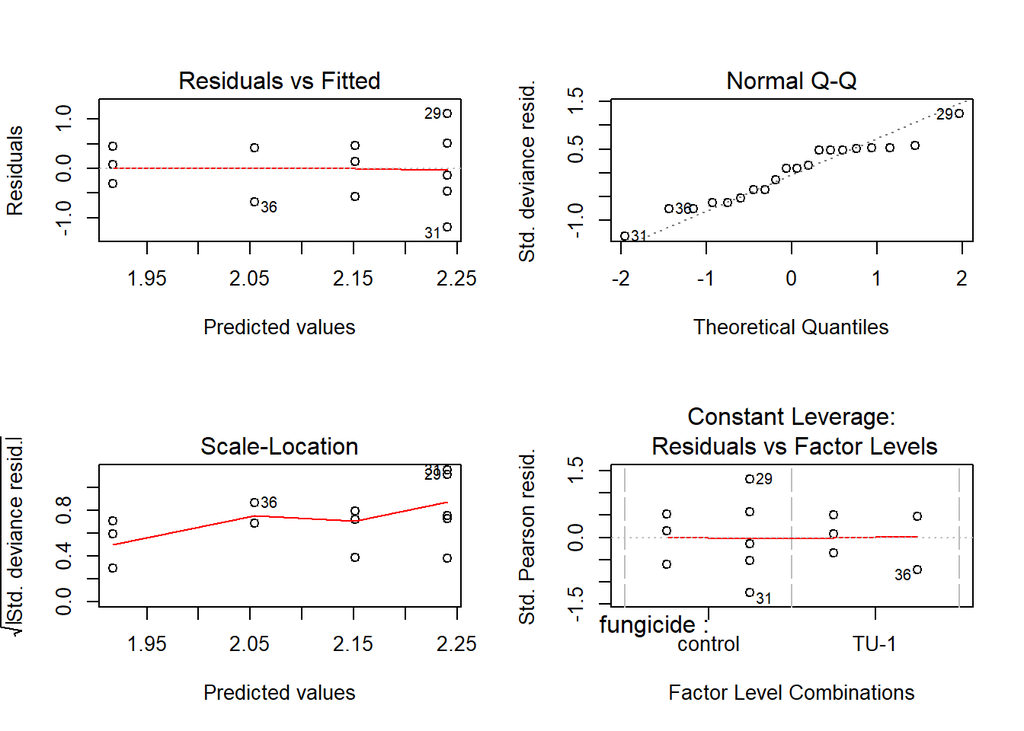

```r
par(mfrow = c(2, 2))
plot(mod1_DE_Spec)
```

Model fits

##### 1.5.1.1.3 Investigate Interactions

```r
drop1(mod1_DE_Spec, test = 'Chisq')
```

```
## Single term deletions
##
## Model:
## species ~ fungicide + cycle + fungicide:cycle
##                 Df Deviance    AIC      LRT Pr(>Chi)
## <none>               6.0640 92.706
## fungicide:cycle  1   6.0874 90.730 0.023385   0.8785
```

No interaction found, model again without interaction

##### 1.5.1.1.4 Fit model without interaction

```r
mod1_DE_Spec_wo2 <- glm(species ~ fungicide + cycle,
                        data   = data_ger,
                        family = 'poisson')
```

##### 1.5.1.1.5 Diagnose model

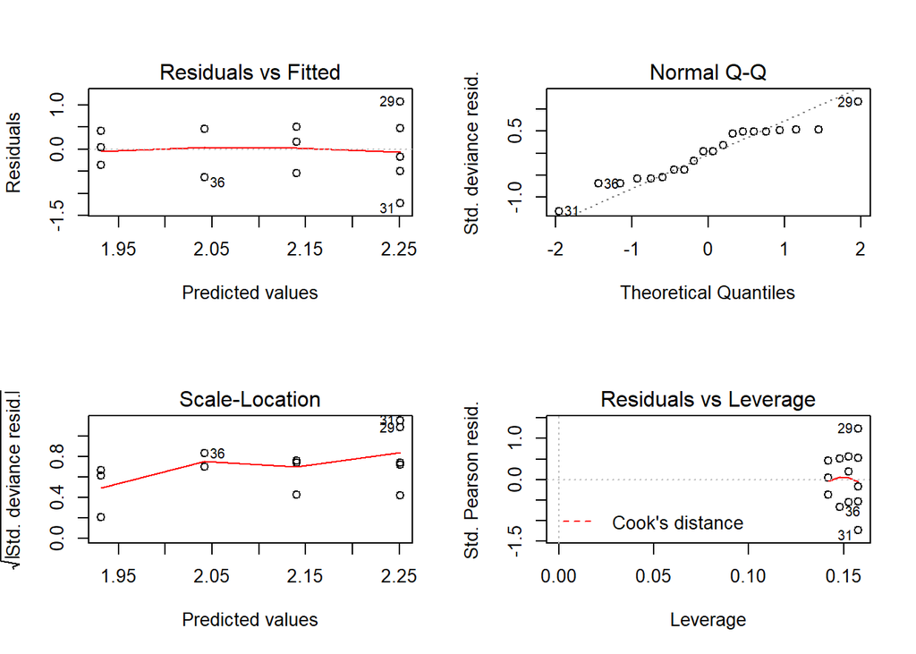

```r
par(mfrow = c(2, 2))
plot(mod1_DE_Spec_wo2)
```

Model fits

##### 1.5.1.1.6 Investigate significance of parameters

```r
drop1(mod1_DE_Spec_wo2, test = 'Chisq')
```

```
## Single term deletions
##
## Model:
## species ~ fungicide + cycle
##           Df Deviance    AIC     LRT Pr(>Chi)
## <none>         6.0874 90.730
## fungicide  1   7.8636 90.506 1.77623   0.1826
## cycle      1   6.5846 89.227 0.49719   0.4807
```

### 1.5.2 Denmark

#### 1.5.2.1 Model the data

##### 1.5.2.1.1 Fit model

since we have count data usage of a glm with poisson distribution

```r
mod1_DK_Spec <- glm(species ~ fungicide + cycle + fungicide:cycle,
                    data   = data_DK,
                    family = 'poisson')
```

##### 1.5.2.1.2 Diagnose model

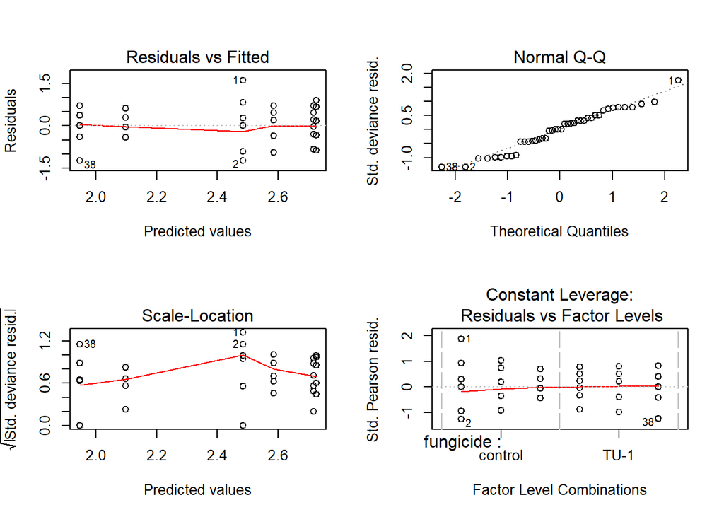

```r
par(mfrow = c(2, 2))
plot(mod1_DK_Spec)
```

##### 1.5.2.1.3 Investigate Interactions

```r
drop1(mod1_DK_Spec, test = 'Chisq')
```

```
## Single term deletions
##
## Model:
## species ~ fungicide + cycle + fungicide:cycle
##                 Df Deviance    AIC    LRT Pr(>Chi)
## <none>               17.925 208.89
## fungicide:cycle  2   22.063 209.03 4.1382   0.1263
```

No interaction found, model again without interaction

##### 1.5.2.1.4 Fit model without interaction

```r
mod1_DK_Spec_wo2 <- glm(species ~ fungicide + cycle,
                        data   = data_DK,
                        family = 'poisson')
```

##### 1.5.2.1.5 Diagnose model

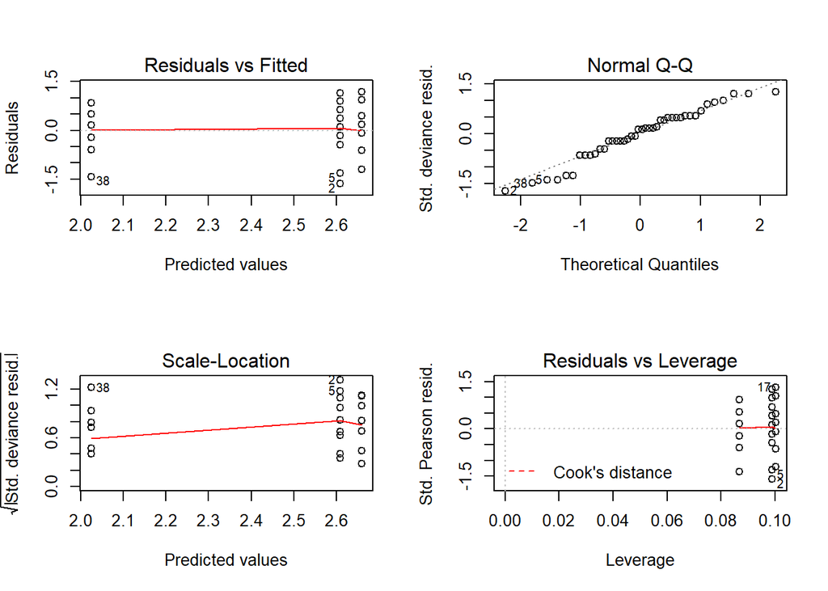

```r
par(mfrow = c(2, 2))
plot(mod1_DK_Spec_wo2)
```

```r
drop1(mod1_DK_Spec_wo2, test = 'Chisq')
```

```
## Single term deletions
##
## Model:
## species ~ fungicide + cycle
##           Df Deviance    AIC    LRT  Pr(>Chi)
## <none>         22.063 209.03
## fungicide  1   22.063 207.03  0.000         1
## cycle      2   56.808 239.78 34.745 2.852e-08 ***
## ---
## Signif. codes:  0 '***' 0.001 '**' 0.01 '*' 0.05 '.' 0.1 ' ' 1
```

### 1.5.3 Sweden

#### 1.5.3.1 Look at the data

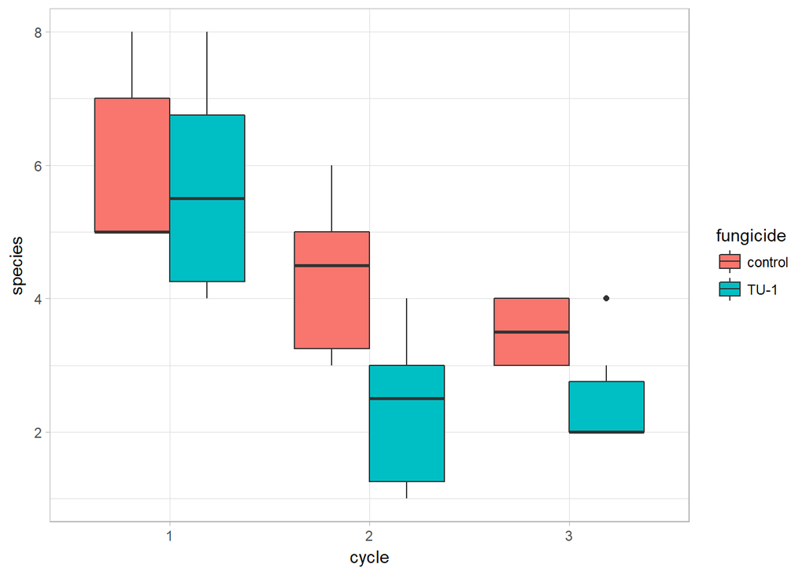

```r
ggplot(data_SW, aes(x = cycle, y = species, fill = fungicide)) +
  geom_boxplot() +
  theme_light()
```

#### 1.5.3.2 Model the data

##### 1.5.3.2.1 Fit model

since we have count data usage of a glm with poisson distribution

```r
mod1_SW_Spec <- glm(species ~ fungicide + cycle + fungicide:cycle,
           data = data_SW, family = 'poisson')
```

##### 1.5.3.2.2 Diagnose model

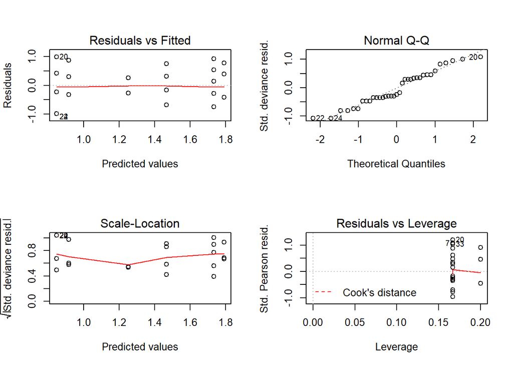

```r
par(mfrow = c(2, 2))
plot(mod1_SW_Spec)
```

##### 1.5.3.2.3 Investigate Interactions

```r
drop1(mod1_SW_Spec, test = 'Chisq')
```

```
## Single term deletions
##
## Model:
## species ~ fungicide + cycle + fungicide:cycle
##                 Df Deviance   AIC    LRT Pr(>Chi)
## <none>               10.378 133.2
## fungicide:cycle  2   12.277 131.1 1.8983   0.3871
```

No interaction found, model again without interaction

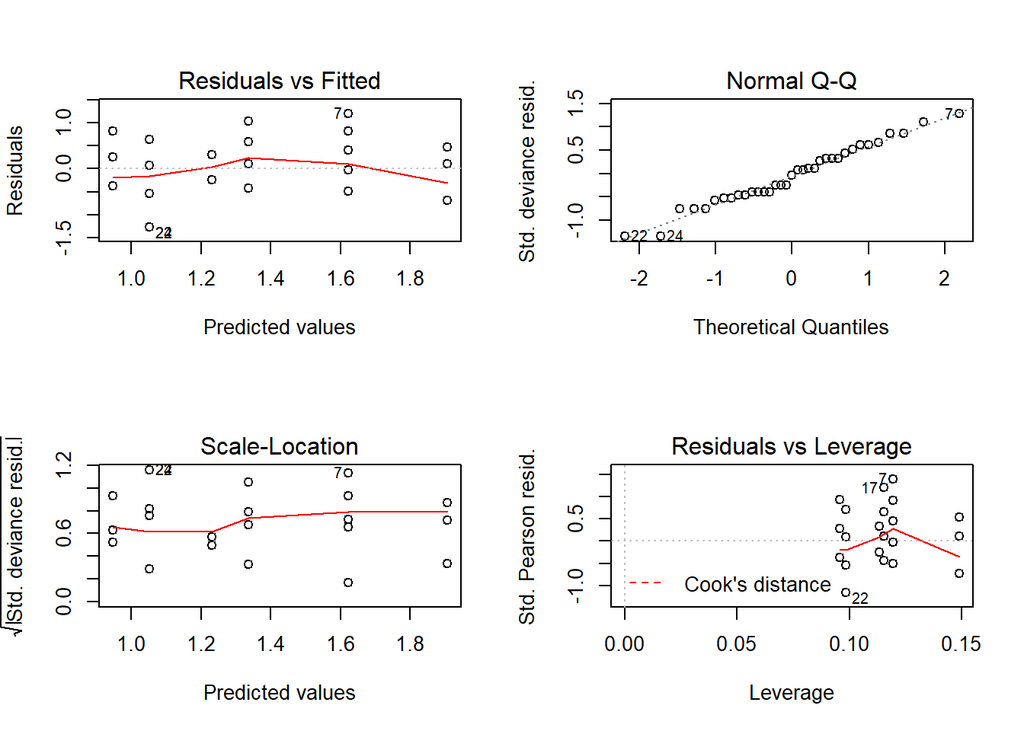

```r
mod1_SW_Spec_wo2 <- glm(species ~ fungicide + cycle,
           data = data_SW, family = 'poisson')

par(mfrow = c(2, 2))
plot(mod1_SW_Spec_wo2)
```

##### 1.5.3.2.4 Investigate significance of parameters

```r
drop1(mod1_SW_Spec_wo2, test = 'Chisq')
```

```
## Single term deletions
##
## Model:
## species ~ fungicide + cycle
##           Df Deviance    AIC     LRT Pr(>Chi)
## <none>         12.277 131.10
## fungicide  1   15.091 131.91  2.8144 0.093419 .
## cycle      2   25.436 140.25 13.1595 0.001388 **
## ---
## Signif. codes:  0 '***' 0.001 '**' 0.01 '*' 0.05 '.' 0.1 ' ' 1
```

## 1.6 Stress responses of single hyphomycete taxa

In this part we used the lowest level of determination reached in the different biogeographical regions. Only taxa occuring in at least two biogeographical regions are analysed.

#### 1.6.0.1 Sweden

Looking closer at following species: * Articulospora tetracladia * Flagellospora curvula * Alatospora sp. * Anguillospora sp.

##### 1.6.0.1.1 Articulospora tetracladia

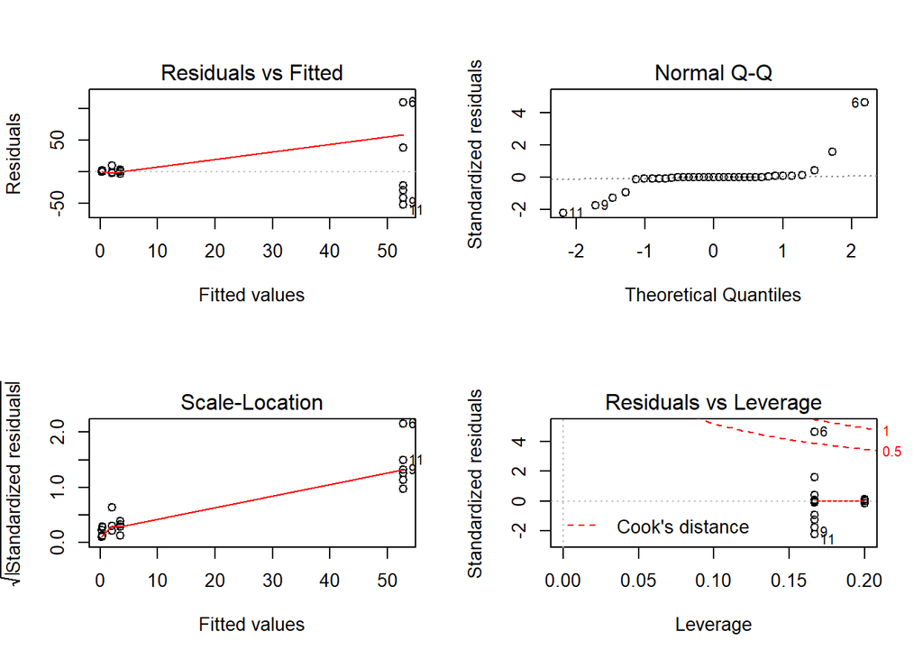

```r
mod1_SW_At <- lm(Articulospora.tetracladia ~ fungicide + cycle  +
             fungicide:cycle,
           data = data_conid_SW)

par(mfrow = c(2, 2))
plot(mod1_SW_At)
```

Model shows outliers, they need to be excluded.

```r
data_conid_SW_excl <- data_conid_SW[-c(6,7,8,9, 10, 16),]
```

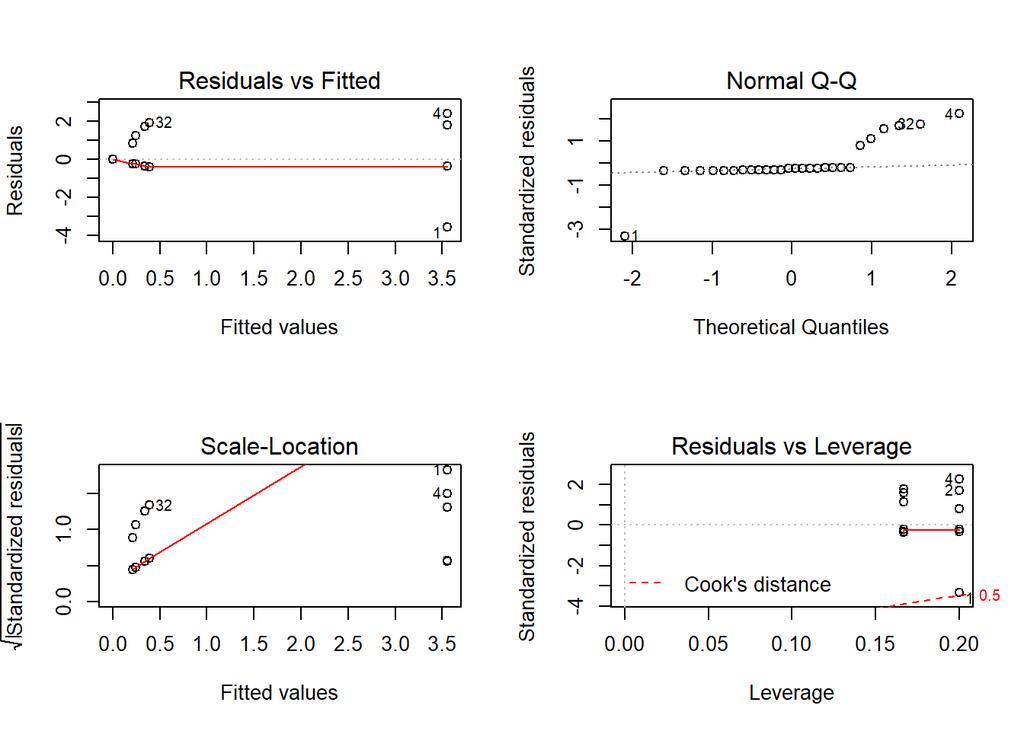

```r
mod1_SW_At_ex <- lm(Articulospora.tetracladia ~ fungicide + cycle  +
             fungicide:cycle,
           data = data_conid_SW_excl)

par(mfrow = c(2, 2))
plot(mod1_SW_At_ex)
```

```r
drop1(mod1_SW_At_ex, test = 'F')
```

```
## Single term deletions
##
## Model:
## Articulospora.tetracladia ~ fungicide + cycle + fungicide:cycle
##                 Df Sum of Sq    RSS    AIC F value  Pr(>F)
## <none>                       32.810 15.580
## fungicide:cycle  2    9.3937 42.204 18.881  3.2925 0.05528 .
## ---
## Signif. codes:  0 '***' 0.001 '**' 0.01 '*' 0.05 '.' 0.1 ' ' 1
```

no significant relationship, so redo model without interaction

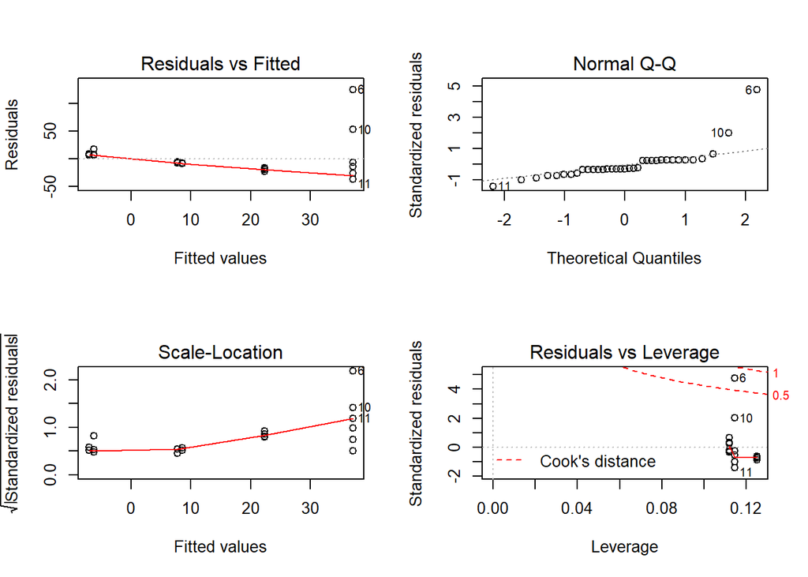

```r
mod1_SW_At_wo <- lm(Articulospora.tetracladia ~ fungicide + cycle,
           data = data_conid_SW)

par(mfrow = c(2, 2))
plot(mod1_SW_At_wo)
```

exclude outlier:

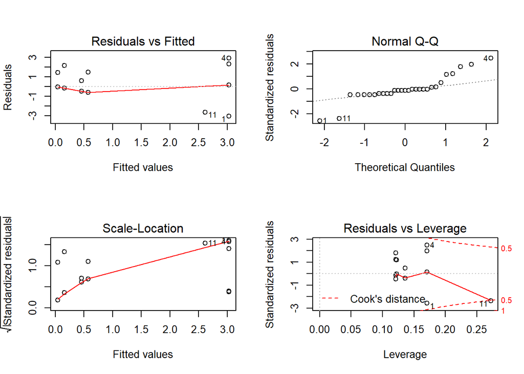

```r
mod1_SW_At_wo_ex <- lm(Articulospora.tetracladia ~ fungicide + cycle,
           data = data_conid_SW_excl)

par(mfrow = c(2, 2))
plot(mod1_SW_At_wo_ex)
```

```r
drop1(mod1_SW_At_wo_ex, test = 'F')
```

```
## Single term deletions
##
## Model:
## Articulospora.tetracladia ~ fungicide + cycle
##           Df Sum of Sq    RSS    AIC F value   Pr(>F)
## <none>                 42.204 18.881
## fungicide  1    1.1367 43.340 17.652  0.6733 0.419652
## cycle      2   27.5496 69.753 29.452  8.1597 0.001872 **
## ---
## Signif. codes:  0 '***' 0.001 '**' 0.01 '*' 0.05 '.' 0.1 ' ' 1
```

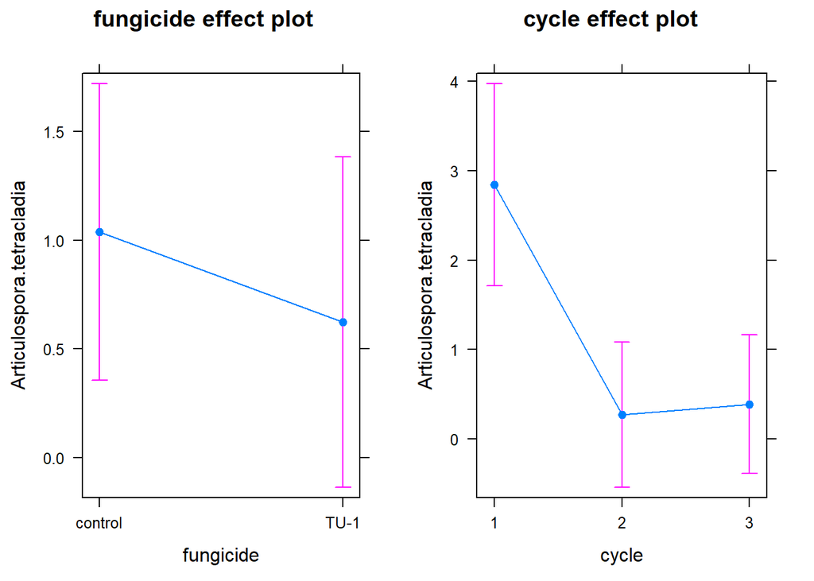

```r
plot(allEffects(mod1_SW_At_wo_ex))
```

##### 1.6.0.1.2 Flagellospora curvula

```r
mod1_SW_Fc <- lm(Flagellospora.curvula ~ fungicide + cycle  +
             fungicide:cycle ,
           data = data_conid_SW)
```

Check model fitting

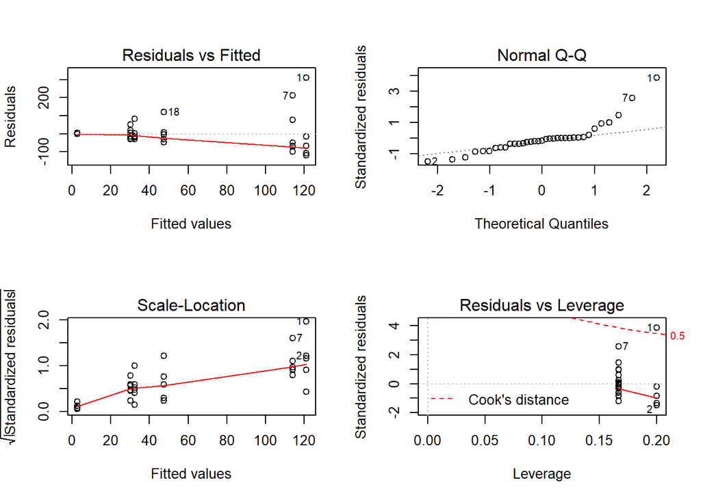

```r
par(mfrow = c(2, 2))
plot(mod1_SW_Fc)
```

Model shows outliers, they need to be excluded.

```r
data_conid_SW_excl_1 <- data_conid_SW[-c(1, 7),]
```

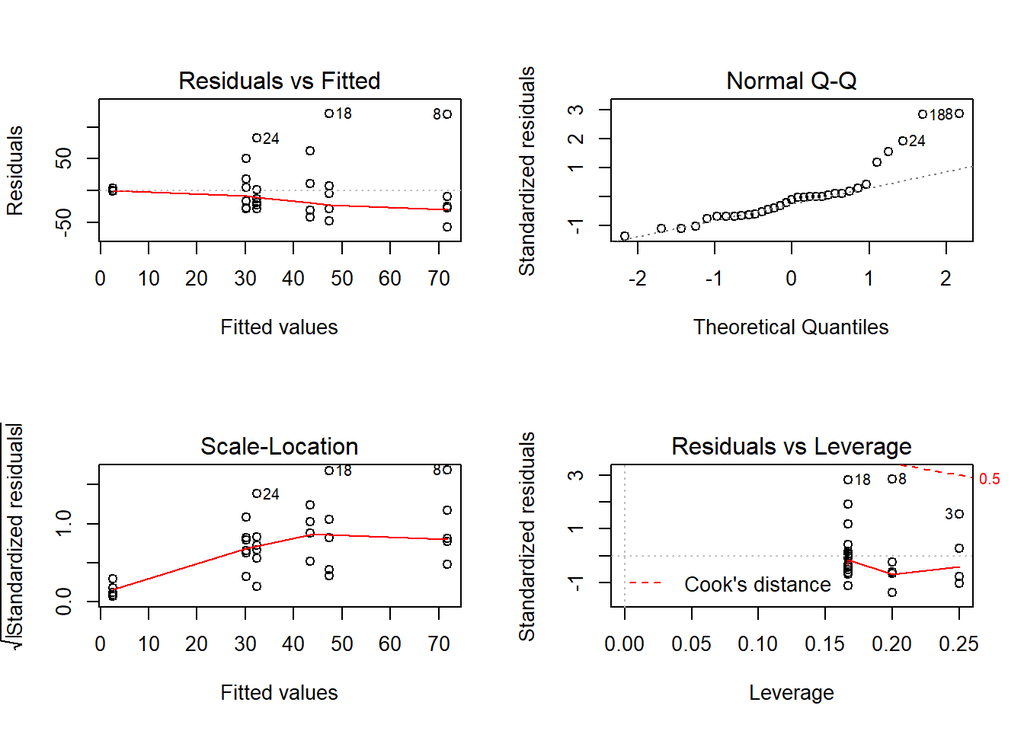

```r
mod1_SW_Fc_ex <- lm(Flagellospora.curvula ~ fungicide + cycle + fungicide:cycle ,
           data = data_conid_SW_excl_1)

par(mfrow = c(2, 2))
plot(mod1_SW_Fc_ex)
```

still not perfect, but when regaring Cook’s distance in Residuals vs Leverage graph model seems to to work

```r
drop1(mod1_SW_Fc_ex, test = 'F')
```

```
## Single term deletions
##
## Model:
## Flagellospora.curvula ~ fungicide + cycle + fungicide:cycle
##                 Df Sum of Sq   RSS    AIC F value Pr(>F)
## <none>                       59446 259.38
## fungicide:cycle  2    5270.5 64716 258.18  1.1969 0.3176
```

no significant relationship, so redo model without interaction

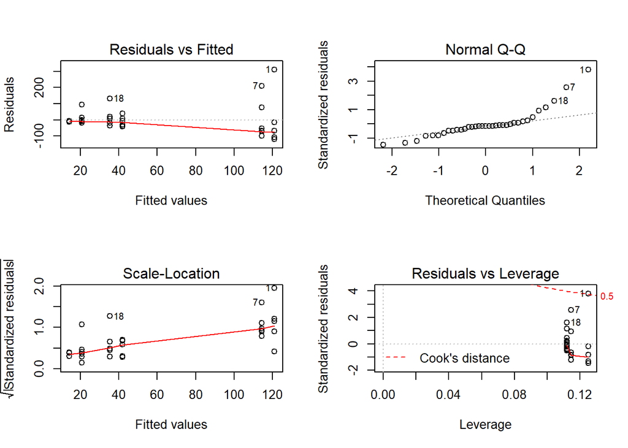

```r
mod1_SW_Fc_wo <- lm(Flagellospora.curvula ~ fungicide + cycle,
           data = data_conid_SW)

par(mfrow = c(2, 2))
plot(mod1_SW_Fc_wo)
```

Model shows again outlier

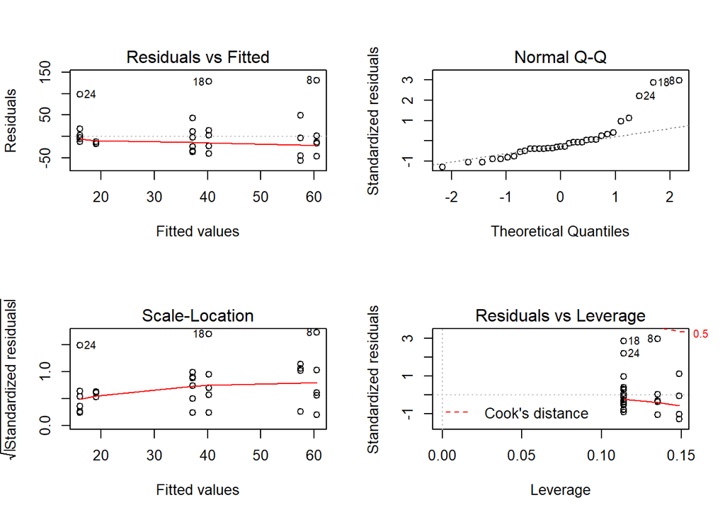

```r
mod1_SW_Fc_wo_ex <- lm(Flagellospora.curvula ~ fungicide + cycle,
           data = data_conid_SW_excl_1)

par(mfrow = c(2, 2))
plot(mod1_SW_Fc_wo_ex)
```

still not perfect, but when regaring Cook’s distance in Residuals vs Leverage graph model seems to work

```r
drop1(mod1_SW_Fc_wo_ex, test = 'F')
```

```
## Single term deletions
##
## Model:
## Flagellospora.curvula ~ fungicide + cycle
##           Df Sum of Sq   RSS    AIC F value Pr(>F)
## <none>                 64716 258.18
## fungicide  1      75.1 64791 256.22  0.0337 0.8557
## cycle      2    8933.4 73650 258.45  2.0016 0.1534
```

##### 1.6.0.1.3 Alatospora sp.

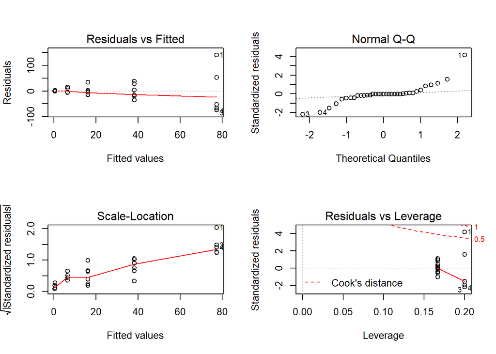

```r
mod1_SW_Als <- lm(Alatospora.sp. ~ fungicide + cycle  +  fungicide:cycle ,
           data = data_conid_SW)

par(mfrow = c(2, 2))
plot(mod1_SW_Als)
```

Exclude outliers

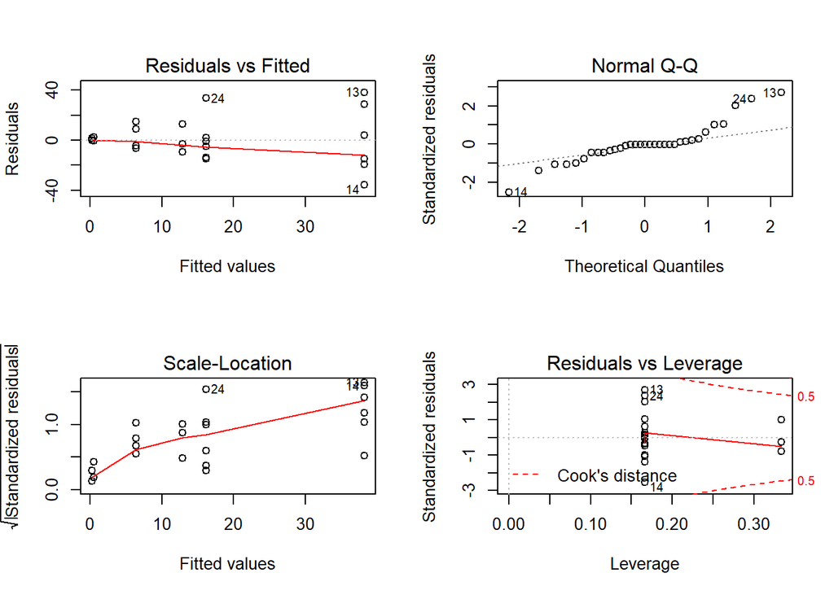

```r
data_conid_SW_excl <- data_conid_SW[-c(1,2),]

mod1_SW_Als_ex <- lm(Alatospora.sp. ~ fungicide + cycle  +  fungicide:cycle ,
           data = data_conid_SW_excl)

par(mfrow = c(2, 2))
plot(mod1_SW_Als_ex)
```

```r
drop1(mod1_SW_Als_ex, test = 'F')
```

```
## Single term deletions
##
## Model:
## Alatospora.sp. ~ fungicide + cycle + fungicide:cycle
##                 Df Sum of Sq    RSS    AIC F value  Pr(>F)
## <none>                       6453.8 186.10
## fungicide:cycle  2    1364.9 7818.6 188.44  2.8551 0.07502 .
## ---
## Signif. codes:  0 '***' 0.001 '**' 0.01 '*' 0.05 '.' 0.1 ' ' 1
```

Interaction not significant, reduce model.

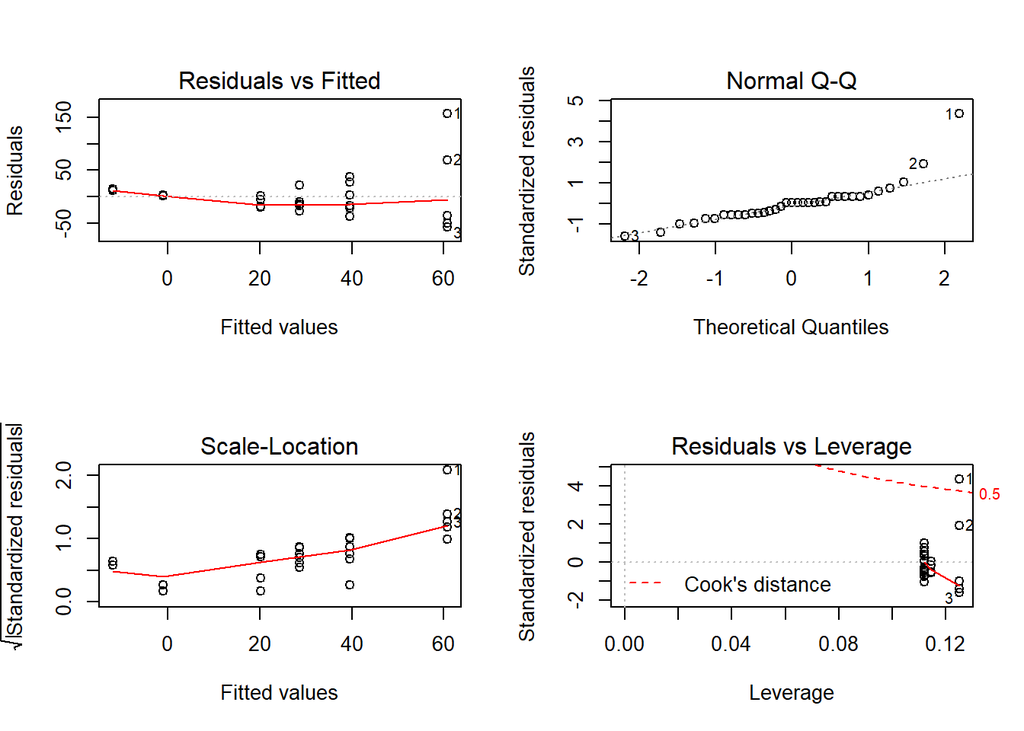

```r
mod1_SW_Als_wo <- lm(Alatospora.sp. ~ fungicide + cycle,
           data = data_conid_SW)

par(mfrow = c(2, 2))
plot(mod1_SW_Als_wo)
```

Exclude outliers

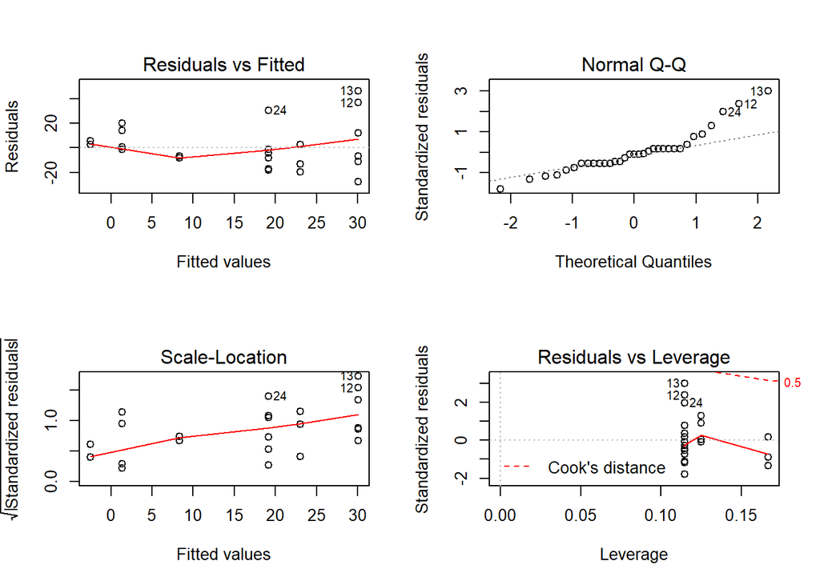

```r
mod1_SW_Als_wo_ex <- lm(Alatospora.sp. ~ fungicide + cycle ,
           data = data_conid_SW_excl)

par(mfrow = c(2, 2))
plot(mod1_SW_Als_wo_ex)
```

```r
drop1(mod1_SW_Als_wo_ex, test = 'F')
```

```
## Single term deletions
##
## Model:
## Alatospora.sp. ~ fungicide + cycle
##           Df Sum of Sq     RSS    AIC F value    Pr(>F)
## <none>                  7818.6 188.44
## fungicide  1    3773.4 11592.1 199.43  13.996 0.0008041 ***
## cycle      2     727.9  8546.6 187.37   1.350 0.2750605
## ---
## Signif. codes:  0 '***' 0.001 '**' 0.01 '*' 0.05 '.' 0.1 ' ' 1
```

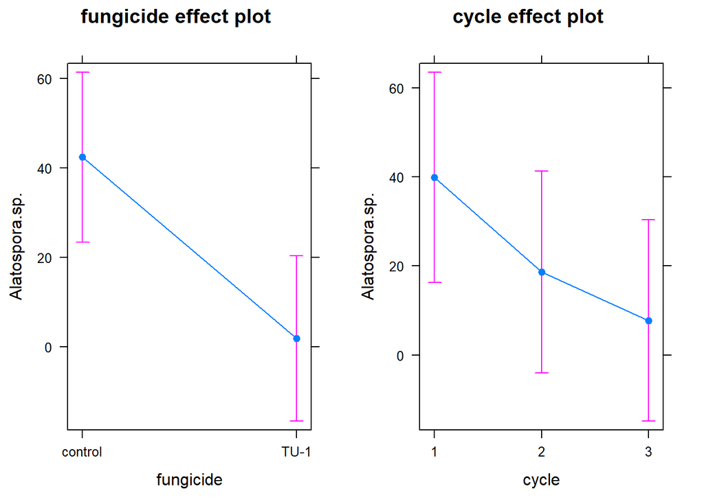

```r
plot(allEffects(mod1_SW_Als_wo))
```

##### 1.6.0.1.4 Anguillospora sp.

```r
mod1_SW_As <- lm(Anguillospora.sp. ~ fungicide + cycle +
             fungicide:cycle,
           data = data_conid_SW)
```

Check model fitting

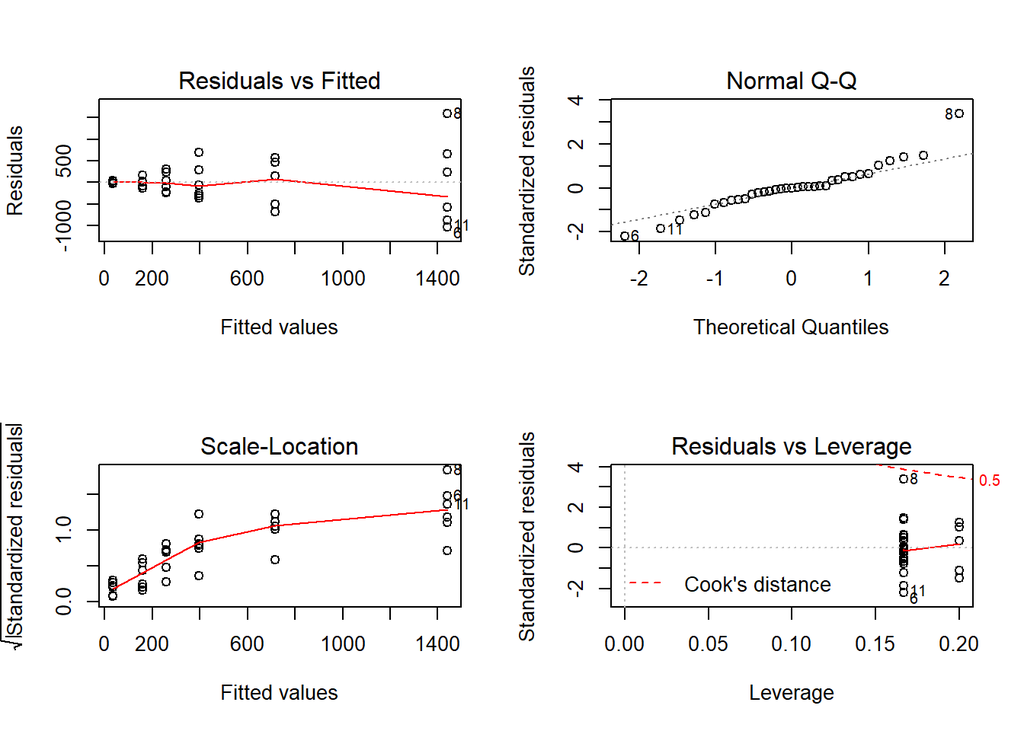

```r
par(mfrow = c(2, 2))
plot(mod1_SW_As)
```

Model fits.

```r
drop1(mod1_SW_As, test = 'F')
```

```
## Single term deletions
##
## Model:
## Anguillospora.sp. ~ fungicide + cycle + fungicide:cycle
##                 Df Sum of Sq     RSS    AIC F value  Pr(>F)
## <none>                       7680624 442.46
## fungicide:cycle  2   1368903 9049527 444.20  2.5843 0.09272 .
## ---
## Signif. codes:  0 '***' 0.001 '**' 0.01 '*' 0.05 '.' 0.1 ' ' 1
```

Interaction not significant, repeat with model without interaction.

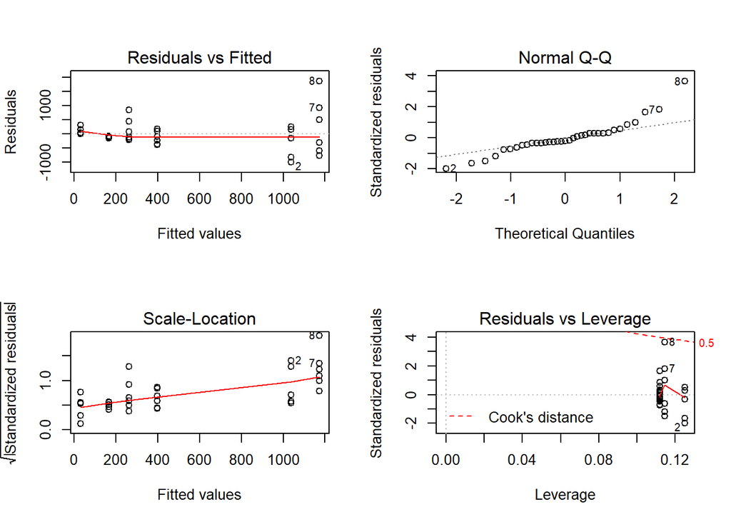

```r
mod1_SW_As_wo <- lm(Anguillospora.sp. ~ fungicide + cycle ,
           data = data_conid_SW)

par(mfrow = c(2, 2))
plot(mod1_SW_As_wo)
```

```r
drop1(mod1_SW_As_wo, test = 'F')
```

```
## Single term deletions
##
## Model:
## Anguillospora.sp. ~ fungicide + cycle
##           Df Sum of Sq      RSS    AIC F value    Pr(>F)
## <none>                  9049527 444.20
## fungicide  1    159012  9208539 442.81  0.5447 0.4660374
## cycle      2   6324725 15374252 458.75 10.8330 0.0002706 ***
## ---
## Signif. codes:  0 '***' 0.001 '**' 0.01 '*' 0.05 '.' 0.1 ' ' 1
```

### 1.6.1 Germany

Looking closer at following species: * Articulospora tetracladia * Flagellospora curvula * Tetrachaetum elegans * Tetracladium sp. * Tetracladium marchalianum

##### 1.6.1.0.1 Articulospora tetracladia

```r
mod1_DE_At <- lm(Articulospora.tetracladia ~ fungicide + cycle  +
             fungicide:cycle,
           data = data_conid_DE)
```

Check model fitting

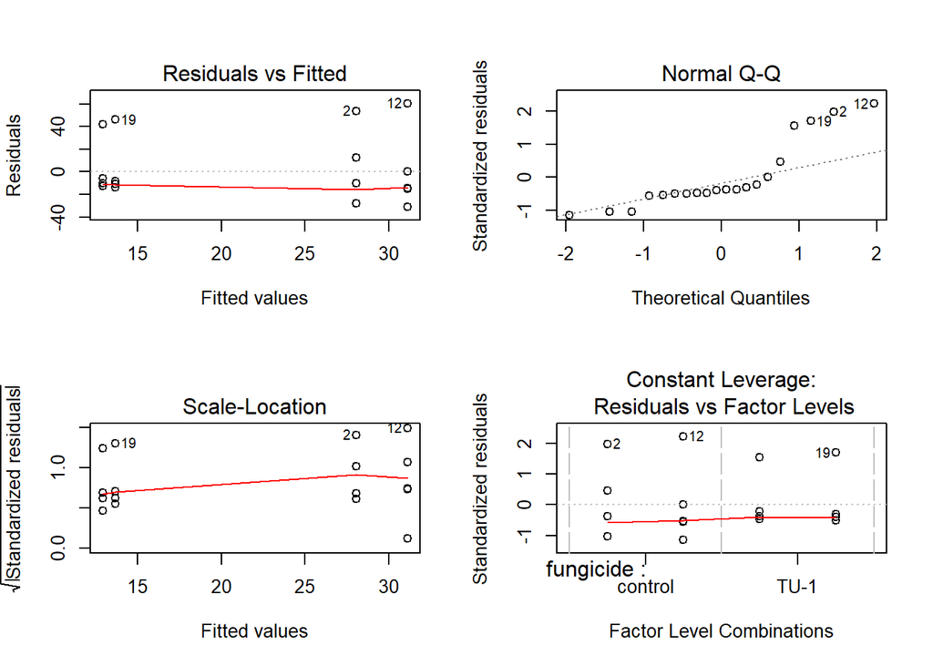

```r
par(mfrow = c(2, 2))
plot(mod1_DE_At)
```

ok

```r
drop1(mod1_DE_At, test = 'F')
```

```
## Single term deletions
##
## Model:
## Articulospora.tetracladia ~ fungicide + cycle + fungicide:cycle
##                 Df Sum of Sq   RSS    AIC F value Pr(>F)
## <none>                       14687 139.98
## fungicide:cycle  1     6.806 14694 137.99  0.0074 0.9324
```

Interaction not significant, reduce model.

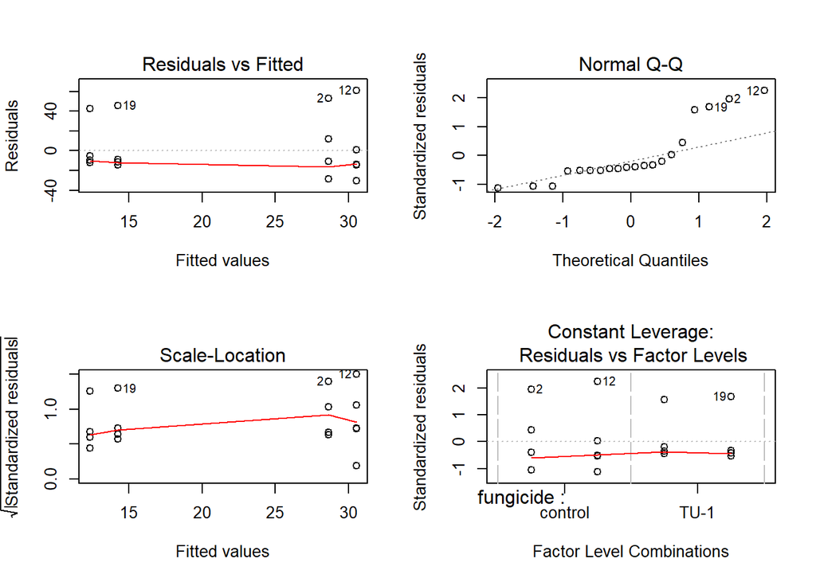

```r
mod1_DE_At_wo2 <- lm(Articulospora.tetracladia ~ fungicide + cycle,
           data = data_conid_DE)

par(mfrow = c(2, 2))
plot(mod1_DE_At_wo2)
```

ok

```r
drop1(mod1_DE_At_wo2, test = 'F')
```

```
## Single term deletions
##
## Model:
## Articulospora.tetracladia ~ fungicide + cycle
##           Df Sum of Sq   RSS    AIC F value Pr(>F)
## <none>                 14694 137.99
## fungicide  1    1325.9 16020 137.72  1.5339 0.2324
## cycle      1      18.4 14712 136.01  0.0213 0.8857
```